# R 통계

## 5. 사회연결망 분석

### —————————————————————————–

### 사회연결망 분석

### —————————————————————————–

```r
#data <- read.table("http://sna.stanford.edu/sna_R_labs/data/Krack-High-Tec-edgelist-Advice.txt")
#write.table(data, file="data/ADV_4_5_001.csv", append=FALSE, quote=FALSE, sep=",", row.names=FALSE)
data01 <- read.table("data/ADV_4_5_001.csv", header=TRUE, sep=",",
                     stringsAsFactors=FALSE, na.strings=c('NIL'),
                     comment.char="#", encoding="UTF-8")
colnames(data01) <- c("ego", "alter", "advice_tie")

#data <- read.table("http://sna.stanford.edu/sna_R_labs/data/Krack-High-Tec-edgelist-Friendship.txt")
#write.table(data, file="data/ADV_4_5_002.csv", append=FALSE, quote=FALSE, sep=",", row.names=FALSE)
data02 <- read.table("data/ADV_4_5_002.csv", header=TRUE, sep=",",
                     stringsAsFactors=FALSE, na.strings=c('NIL'),
                     comment.char="#", encoding="UTF-8")
colnames(data02) <- c("ego", "alter", "friendship_tie")

#data <- read.table("http://sna.stanford.edu/sna_R_labs/data/Krack-High-Tec-edgelist-ReportsTo.txt")
#write.table(data, file="data/ADV_4_5_003.csv", append=FALSE, quote=FALSE, sep=",", row.names=FALSE)
data03 <- read.table("data/ADV_4_5_003.csv", header=TRUE, sep=",",
                     stringsAsFactors=FALSE, na.strings=c('NIL'),
                     comment.char="#", encoding="UTF-8")
colnames(data03) <- c("ego", "alter", "reports_to_tie")

#data <- read.csv("http://sna.stanford.edu/sna_R_labs/data/Krack-High-Tec-Attributes.csv", header = T)
#write.table(data, file="data/ADV_4_5_004.csv", append=FALSE, quote=FALSE, sep=",", row.names=FALSE)
(data04 <- read.table("data/ADV_4_5_004.csv", header=TRUE, sep=",",    #--- vertex의 attribute
                      stringsAsFactors=FALSE, na.strings=c('NIL'),
                      comment.char="#", encoding="UTF-8") )
```

```
##    AGE TENURE LEVEL DEPT
## 1   33  9.333     3    4
## 2   42 19.583     2    4
## 3   40 12.750     3    2
## 4   33  7.500     3    4
## 5   32  3.333     3    2
## 6   59 28.000     3    1
## 7   55 30.000     1    0
## 8   34 11.333     3    1
## 9   62  5.417     3    2
## 10  37  9.250     3    3
## 11  46 27.000     3    3
## 12  34  8.917     3    1
## 13  48  0.250     3    2
## 14  43 10.417     2    2
## 15  40  8.417     3    2
## 16  27  4.667     3    4
## 17  30 12.417     3    1
## 18  33  9.083     2    3
## 19  32  4.833     3    2
## 20  38 11.667     3    2
## 21  36 12.500     2    1
```

```r
which(data01$ego != data02$ego)         #--- 두 데이터의 ego가 동일한지 검사
```

```
## integer(0)
```

```r
which(data01$ego != data03$ego)         #--- 두 데이터의 ego가 동일한지 검사
```

```
## integer(0)
```

```r
which(data01$alter != data02$alter)     #--- 두 데이터의 alter가 동일한지 검사
```

```
## integer(0)
```

```r
which(data01$alter != data03$alter)     #--- 두 데이터의 alter가 동일한지 검사
```

```
## integer(0)
```

```r
#(data <- cbind(data01, data02$friendship_tie, data03$reports_to_tie))
#names(data)[4:5] <- c("friendship_tie", "reports_to_tie")
(data <- data.frame(ego = data01[, 1], alter = data01[, 2], advice_tie = data01[, 3],
                    friendship_tie = data02[, 3], reports_to_tie = data02[, 3]))
```

```
##     ego alter advice_tie friendship_tie reports_to_tie
## 1     1     1          0              0              0
## 2     1     2          1              1              1
## 3     1     3          0              0              0
## 4     1     4          1              1              1
## 5     1     5          0              0              0
## 6     1     6          0              0              0
## 7     1     7          0              0              0
## 8     1     8          1              1              1
## 9     1     9          0              0              0
## 10    1    10          0              0              0
## 11    1    11          0              0              0
## 12    1    12          0              1              1
## 13    1    13          0              0              0
## 14    1    14          0              0              0
```

[output cut: 427 more lines]

```r
(data <- subset(data, (advice_tie > 0 | friendship_tie > 0 | reports_to_tie > 0)))
```

```
##     ego alter advice_tie friendship_tie reports_to_tie
## 2     1     2          1              1              1
## 4     1     4          1              1              1
## 8     1     8          1              1              1
## 12    1    12          0              1              1
## 16    1    16          1              1              1
## 18    1    18          1              0              0
## 21    1    21          1              0              0
## 22    2     1          0              1              1
## 27    2     6          1              0              0
## 28    2     7          1              0              0
## 39    2    18          0              1              1
## 42    2    21          1              1              1
## 43    3     1          1              0              0
## 44    3     2          1              0              0
```

[output cut: 218 more lines]

```r
(attrs <- cbind(1:length(data04[, 1]), data04))
```

```
##    1:length(data04[, 1]) AGE TENURE LEVEL DEPT
## 1                      1  33  9.333     3    4
## 2                      2  42 19.583     2    4
## 3                      3  40 12.750     3    2
## 4                      4  33  7.500     3    4
## 5                      5  32  3.333     3    2
## 6                      6  59 28.000     3    1
## 7                      7  55 30.000     1    0
## 8                      8  34 11.333     3    1
## 9                      9  62  5.417     3    2
## 10                    10  37  9.250     3    3
## 11                    11  46 27.000     3    3
## 12                    12  34  8.917     3    1
## 13                    13  48  0.250     3    2
## 14                    14  43 10.417     2    2
## 15                    15  40  8.417     3    2
## 16                    16  27  4.667     3    4
## 17                    17  30 12.417     3    1
## 18                    18  33  9.083     2    3
## 19                    19  32  4.833     3    2
## 20                    20  38 11.667     3    2
## 21                    21  36 12.500     2    1
```

```r
library(igraph)
#(m <- graph.data.frame(data))          #--- 방향 그래프 생성
(m <- graph.data.frame(d = data, directed = TRUE, vertices = attrs))
```

```
## IGRAPH DN-- 21 232 --
## + attr: name (v/c), AGE (v/n), TENURE (v/n), LEVEL (v/n), DEPT
## | (v/n), advice_tie (e/n), friendship_tie (e/n), reports_to_tie
## | (e/n)
## + edges (vertex names):
##  [1] 1->2  1->4  1->8  1->12 1->16 1->18 1->21 2->1  2->6  2->7  2->18
## [12] 2->21 3->1  3->2  3->4  3->6  3->7  3->8  3->9  3->10 3->11 3->12
## [23] 3->14 3->17 3->18 3->19 3->20 3->21 4->1  4->2  4->6  4->8  4->10
## [34] 4->11 4->12 4->16 4->17 4->18 4->20 4->21 5->1  5->2  5->6  5->7
## [45] 5->8  5->9  5->10 5->11 5->13 5->14 5->16 5->17 5->18 5->19 5->20
## [56] 5->21 6->2  6->7  6->9  6->12 6->17 6->21 7->2  7->6  7->11 7->12
## + ... omitted several edges
```

```r
#--- 그래프
#---     Node : vertex, link : edge
#---     첫번째 컬럼이 두번째 컬럼을 가르키는 방향성 그래프 생성
#---     세번째 이상의 컬럼은 edge의 attribute로 추가됨
#--- directed : TRUE. 방향 그래프, FALSE. 무방향 그래프
#--- vertices : vertex의 속성, 첫번째 열이 vertices의 아이디
#(m <- as.undirected(m, mode = "collapse"))   #--- 무방향 그래프로 변환
#(m <- as.directed(m))                        #--- 방향 그래프로 변환
rm(list = c("data01", "data02", "data03", "data04"))

#--- for 문을 사용한 vertex attribute 지정 방법
#for (i in V(m)) {
#  for (j in names(attrs)) {
#    m <- set.vertex.attribute(m, j, index = i, attrs[i + 1, j])
#  }
#}
#rm(list = c("i", "j", "attrs))

summary(m)
```

```
## IGRAPH DN-- 21 232 --
## + attr: name (v/c), AGE (v/n), TENURE (v/n), LEVEL (v/n), DEPT
## | (v/n), advice_tie (e/n), friendship_tie (e/n), reports_to_tie
## | (e/n)
```

```r
vcount(m)                               #--- Vertex 개수
```

```
## [1] 21
```

```r
V(m)                                    #--- Vertex
```

```
## + 21/21 vertices, named:
##  [1] 1  2  3  4  5  6  7  8  9  10 11 12 13 14 15 16 17 18 19 20 21
```

```r
get.vertex.attribute(m, "name")         #--- Vertex 이름
```

```
##  [1] "1"  "2"  "3"  "4"  "5"  "6"  "7"  "8"  "9"  "10" "11" "12" "13" "14"
## [15] "15" "16" "17" "18" "19" "20" "21"
```

```r
get.vertex.attribute(m, "AGE")          #--- Vertex attribute
```

```
##  [1] 33 42 40 33 32 59 55 34 62 37 46 34 48 43 40 27 30 33 32 38 36
```

```r
get.vertex.attribute(m, "TENURE")       #--- Vertex attribute
```

```
##  [1]  9.333 19.583 12.750  7.500  3.333 28.000 30.000 11.333  5.417  9.250
## [11] 27.000  8.917  0.250 10.417  8.417  4.667 12.417  9.083  4.833 11.667
## [21] 12.500
```

```r
get.vertex.attribute(m, "LEVEL")        #--- Vertex attribute
```

```
##  [1] 3 2 3 3 3 3 1 3 3 3 3 3 3 2 3 3 3 2 3 3 2
```

```r
get.vertex.attribute(m, "DEPT")         #--- Vertex attribute
```

```
##  [1] 4 4 2 4 2 1 0 1 2 3 3 1 2 2 2 4 1 3 2 2 1
```

```r
#--- vertex 라벨   : V(m)$label  : vertex.label
#--- vertex 라벨 크기 : V(m)$label.cex  : vertex.label.cex
#--- #vertex 색상   : V(m)$color  : vertex.color
#--- vertex 크기   : V(m)$size   : vertex.size
#--- #vertex 프레임 : V(m)$frame  : vertex.frame

ecount(m)                               #--- Edge 개수
```

```
## [1] 232
```

```r
E(m)                                    #--- Edge
```

```
## + 232/232 edges (vertex names):
##   [1] 1 ->2  1 ->4  1 ->8  1 ->12 1 ->16 1 ->18 1 ->21 2 ->1  2 ->6  2 ->7
##  [11] 2 ->18 2 ->21 3 ->1  3 ->2  3 ->4  3 ->6  3 ->7  3 ->8  3 ->9  3 ->10
##  [21] 3 ->11 3 ->12 3 ->14 3 ->17 3 ->18 3 ->19 3 ->20 3 ->21 4 ->1  4 ->2
##  [31] 4 ->6  4 ->8  4 ->10 4 ->11 4 ->12 4 ->16 4 ->17 4 ->18 4 ->20 4 ->21
##  [41] 5 ->1  5 ->2  5 ->6  5 ->7  5 ->8  5 ->9  5 ->10 5 ->11 5 ->13 5 ->14
##  [51] 5 ->16 5 ->17 5 ->18 5 ->19 5 ->20 5 ->21 6 ->2  6 ->7  6 ->9  6 ->12
##  [61] 6 ->17 6 ->21 7 ->2  7 ->6  7 ->11 7 ->12 7 ->14 7 ->17 7 ->18 7 ->21
##  [71] 8 ->2  8 ->4  8 ->6  8 ->7  8 ->10 8 ->11 8 ->18 8 ->21 9 ->1  9 ->2
##  [81] 9 ->6  9 ->7  9 ->8  9 ->10 9 ->11 9 ->12 9 ->14 9 ->16 9 ->17 9 ->18
##  [91] 9 ->21 10->1  10->2  10->3  10->4  10->5  10->8  10->9  10->11 10->12
## + ... omitted several edges
```

```r
get.edge.attribute(m, "advice_tie")     #--- Edge attribute
```

```
##   [1] 1 1 1 0 1 1 1 0 1 1 0 1 1 1 1 1 1 1 1 1 1 1 1 1 1 0 1 1 1 1 1 1 1 1 1
##  [36] 1 1 1 1 1 1 1 1 1 1 0 1 1 1 1 1 1 1 1 1 1 0 0 0 0 0 1 1 1 1 1 1 1 1 1
##  [71] 1 1 1 1 1 1 1 1 1 1 1 1 1 1 1 1 1 1 1 1 1 1 1 1 1 1 1 0 1 0 1 1 1 1 1
## [106] 1 1 1 1 0 0 0 1 0 0 0 0 0 0 0 0 0 0 1 0 1 1 1 1 1 0 1 1 1 1 0 1 1 1 1
## [141] 1 1 1 1 1 1 1 1 1 1 1 1 1 1 1 1 1 1 1 1 1 1 1 1 0 1 0 0 1 0 0 0 0 0 0
## [176] 0 0 0 0 1 1 1 1 1 1 1 1 1 1 1 1 1 1 1 1 1 1 1 1 1 1 1 1 1 0 1 1 1 1 1
## [211] 1 1 1 1 1 1 1 1 1 1 1 1 1 1 1 1 1 1 1 1 1 1
```

```r
get.edge.attribute(m, "friendship_tie") #--- Edge attribute
```

```
##   [1] 1 1 1 1 1 0 0 1 0 0 1 1 0 0 0 0 0 0 0 0 0 0 1 0 0 1 0 0 1 1 0 1 0 0 1
##  [36] 1 1 0 0 0 0 1 0 0 0 1 0 1 0 1 0 1 0 1 0 1 1 1 1 1 1 1 0 0 0 0 0 0 0 0
##  [71] 0 1 0 0 0 0 0 0 0 0 0 0 0 0 0 0 0 0 0 0 0 0 0 1 0 1 1 1 0 1 0 0 1 0 0
## [106] 0 1 1 1 1 1 1 0 1 1 1 1 1 1 1 1 1 1 0 1 1 0 0 1 0 1 0 0 0 1 1 0 0 1 0
## [141] 1 0 1 1 0 0 1 0 1 0 0 1 0 0 0 1 0 0 1 1 0 0 1 1 1 1 1 1 1 1 1 1 1 1 1
## [176] 1 1 1 1 1 0 1 0 0 0 0 0 0 0 0 0 0 0 0 0 0 0 1 1 1 1 0 0 1 1 1 1 0 1 0
## [211] 0 0 0 1 0 0 0 0 0 1 0 1 0 0 0 0 0 1 0 1 1 0
```

```r
get.edge.attribute(m, "reports_to_tie") #--- Edge attribute
```

```
##   [1] 1 1 1 1 1 0 0 1 0 0 1 1 0 0 0 0 0 0 0 0 0 0 1 0 0 1 0 0 1 1 0 1 0 0 1
##  [36] 1 1 0 0 0 0 1 0 0 0 1 0 1 0 1 0 1 0 1 0 1 1 1 1 1 1 1 0 0 0 0 0 0 0 0
##  [71] 0 1 0 0 0 0 0 0 0 0 0 0 0 0 0 0 0 0 0 0 0 0 0 1 0 1 1 1 0 1 0 0 1 0 0
## [106] 0 1 1 1 1 1 1 0 1 1 1 1 1 1 1 1 1 1 0 1 1 0 0 1 0 1 0 0 0 1 1 0 0 1 0
## [141] 1 0 1 1 0 0 1 0 1 0 0 1 0 0 0 1 0 0 1 1 0 0 1 1 1 1 1 1 1 1 1 1 1 1 1
## [176] 1 1 1 1 1 0 1 0 0 0 0 0 0 0 0 0 0 0 0 0 0 0 1 1 1 1 0 0 1 1 1 1 0 1 0
## [211] 0 0 0 1 0 0 0 0 0 1 0 1 0 0 0 0 0 1 0 1 1 0
```

```r
get.edge.ids(m, c(20, 18, 21, 18))      #--- 20 -> 18, 21 -> 18인 edge ID 반환
```

```
## [1] 220 231
```

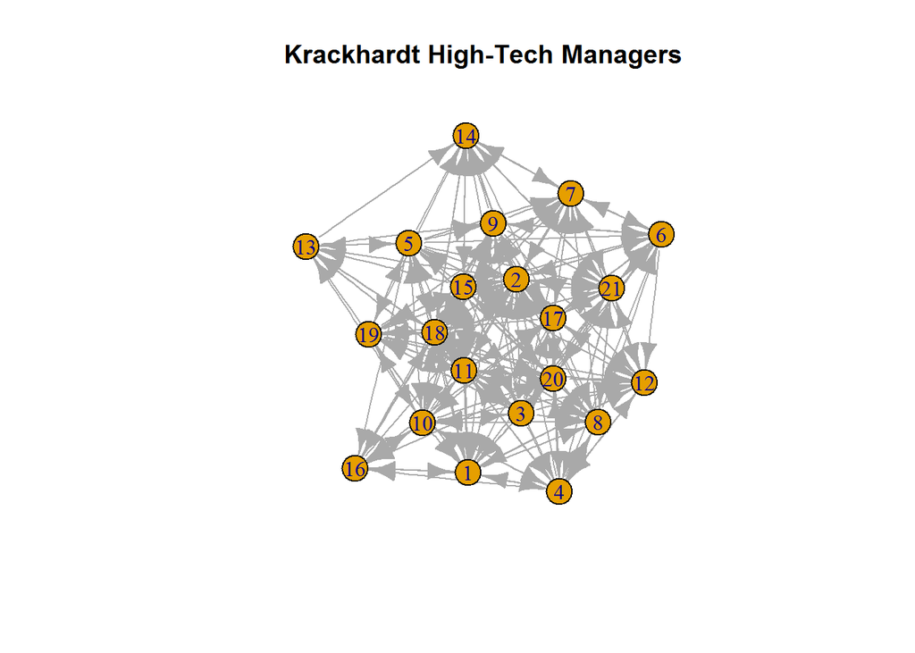

```r
#--- edge 색상        : E(m)$color      : edge.color
#--- edge 화살표 크기 : E(m)$arrow.size : edge.arrow.size
#--- edge 굵기        : E(m)$weight
#--- edge curved      : E(m)$curved <- TRUE, FALSE


###-----------------------------------------------------------------------------
plot(m, main = "Krackhardt High-Tech Managers")   #--- 그래프 그리기
```

```r
(layouts <- layout.fruchterman.reingold(m))   #--- Fruchterman-Reingold Layout
```

```
##            [,1]      [,2]
##  [1,] 0.9475450 0.4581728
##  [2,] 1.5644680 1.4567854
##  [3,] 1.8632748 1.2877033
##  [4,] 1.4106673 0.1436148
##  [5,] 0.8479259 1.5567691
##  [6,] 2.5150046 1.0535288
##  [7,] 2.0998556 1.6461118
##  [8,] 1.7101539 0.3937429
##  [9,] 1.3925760 1.0014996
## [10,] 0.7848546 0.7835928
## [11,] 0.8361826 1.1031330
## [12,] 2.1262714 0.4687905
## [13,] 0.2368813 1.7489041
## [14,] 1.6468922 2.1311034
## [15,] 1.2757998 1.4367418
## [16,] 0.3029865 0.4729240
## [17,] 1.7071275 0.8852059
## [18,] 1.0769949 1.1912822
## [19,] 1.1219493 1.9061122
## [20,] 1.3558374 0.6175218
## [21,] 2.1290161 0.9876598
```

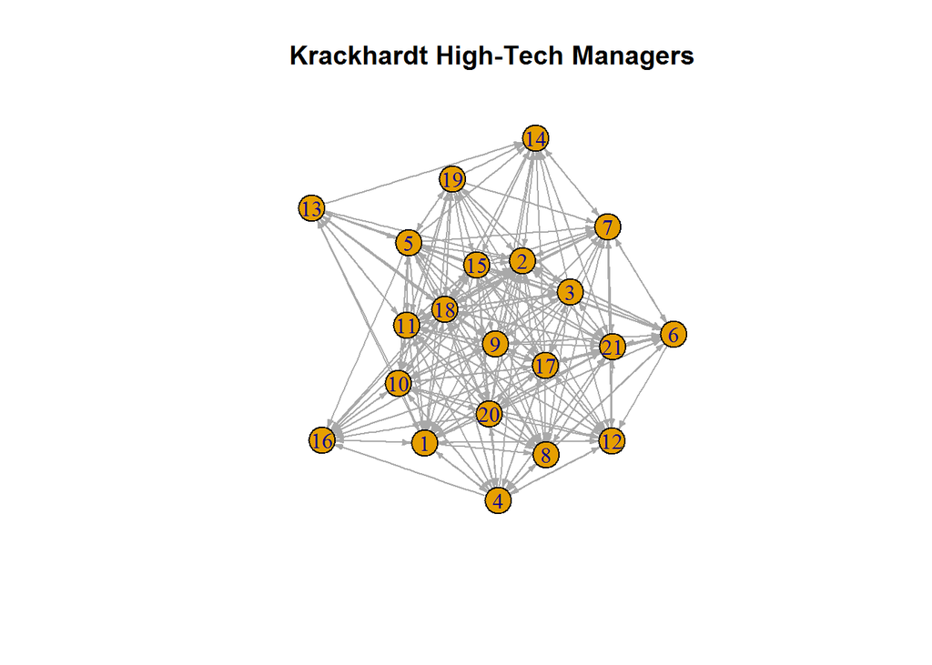

```r
plot(m, layout = layouts, main = "Krackhardt High-Tech Managers",
     edge.arrow.size = .3)
```

```r
#--- vertex 색상 지정
colorStr <- c("Black", "Red", "Blue", "Yellow", "Green")
(vcolors <- get.vertex.attribute(m, "DEPT"))
```

```
##  [1] 4 4 2 4 2 1 0 1 2 3 3 1 2 2 2 4 1 3 2 2 1
```

```r
vcolors[vcolors == 0] <- colorStr[1]
vcolors[vcolors == 1] <- colorStr[2]
vcolors[vcolors == 2] <- colorStr[3]
vcolors[vcolors == 3] <- colorStr[4]
vcolors[vcolors == 4] <- colorStr[5]
vcolors
```

```
##  [1] "Green"  "Green"  "Blue"   "Green"  "Blue"   "Red"    "Black"
##  [8] "Red"    "Blue"   "Yellow" "Yellow" "Red"    "Blue"   "Blue"
## [15] "Blue"   "Green"  "Red"    "Yellow" "Blue"   "Blue"   "Red"
```

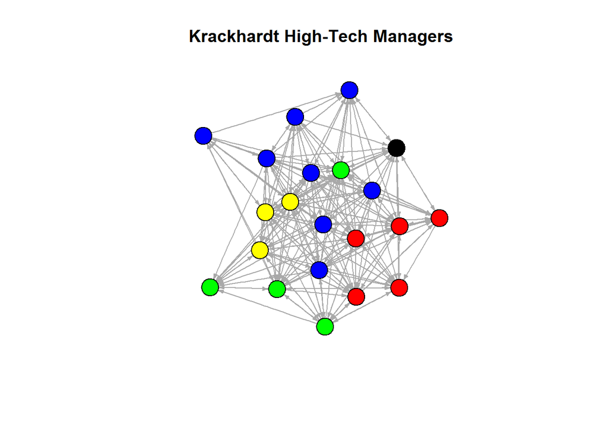

```r
plot(m, layout = layouts, main = "Krackhardt High-Tech Managers",
     vertex.color = vcolors, vertex.label = NA,
     edge.arrow.size = .3)
```

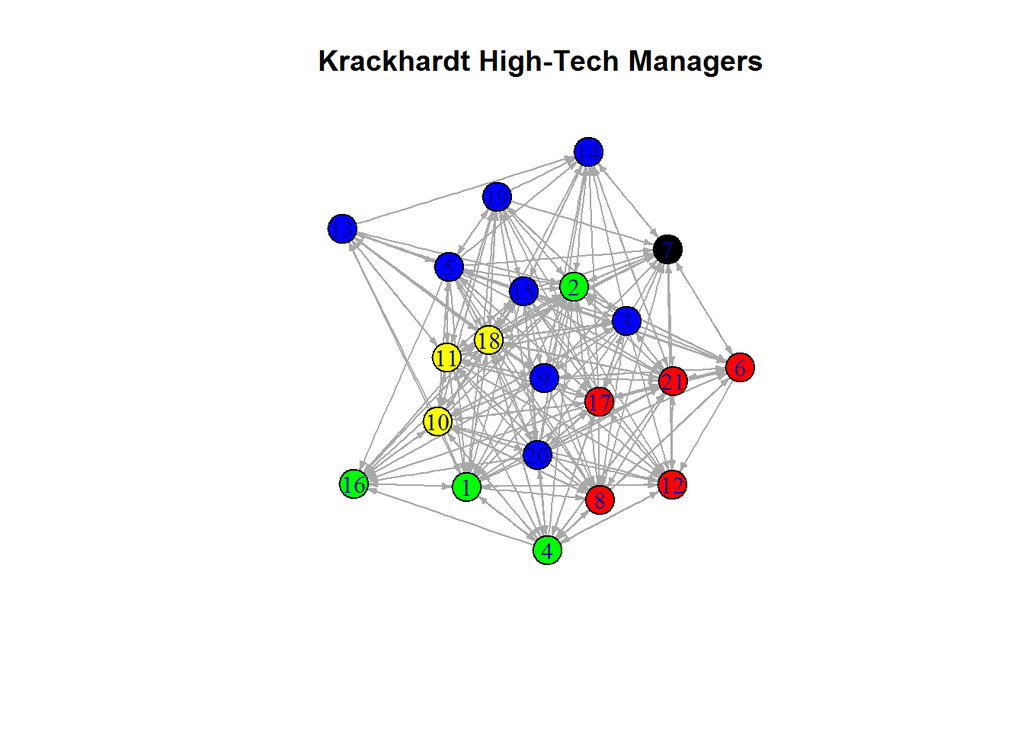

```r
plot(m, layout = layouts, main = "Krackhardt High-Tech Managers",
     vertex.color = vcolors,
     edge.arrow.size = .3)
```

```r
rm(colorStr)

#--- vertex 크기 지정
(vsizes <- get.vertex.attribute(m, "TENURE"))
```

```
##  [1]  9.333 19.583 12.750  7.500  3.333 28.000 30.000 11.333  5.417  9.250
## [11] 27.000  8.917  0.250 10.417  8.417  4.667 12.417  9.083  4.833 11.667
## [21] 12.500
```

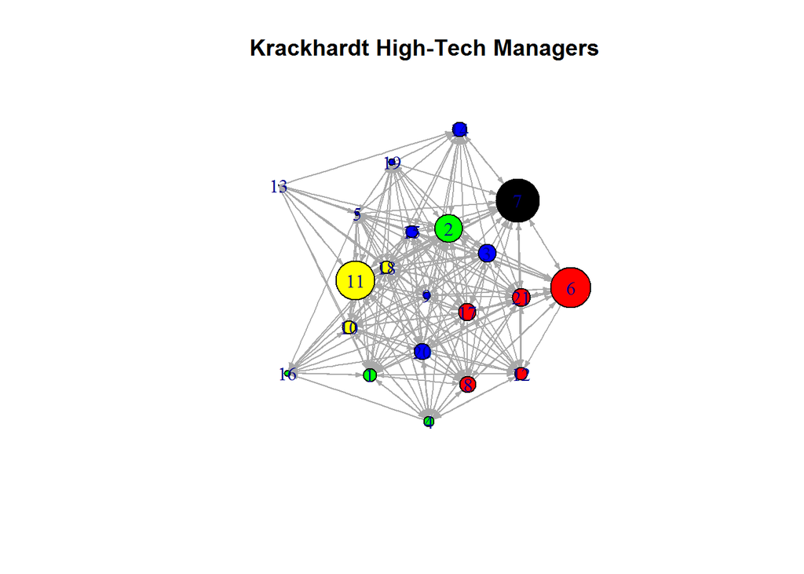

```r
plot(m, layout = layouts, main = "Krackhardt High-Tech Managers",
     vertex.color = vcolors, vertex.size = vsizes,
     edge.arrow.size = .3)
```

```r
#--- edge 색상 지정
(colorStr <- c(rgb(1, 0, 0, .5), rgb(0, 0, 1, .5), rgb(0, 0, 0, .5)))
```

```
## [1] "#FF000080" "#0000FF80" "#00000080"
```

```r
#--- rgb : red, green, blue, alpha (투명도)
(ecolors <- 1:length(E(m)))
```

```
##   [1]   1   2   3   4   5   6   7   8   9  10  11  12  13  14  15  16  17
##  [18]  18  19  20  21  22  23  24  25  26  27  28  29  30  31  32  33  34
##  [35]  35  36  37  38  39  40  41  42  43  44  45  46  47  48  49  50  51
##  [52]  52  53  54  55  56  57  58  59  60  61  62  63  64  65  66  67  68
##  [69]  69  70  71  72  73  74  75  76  77  78  79  80  81  82  83  84  85
##  [86]  86  87  88  89  90  91  92  93  94  95  96  97  98  99 100 101 102
## [103] 103 104 105 106 107 108 109 110 111 112 113 114 115 116 117 118 119
## [120] 120 121 122 123 124 125 126 127 128 129 130 131 132 133 134 135 136
## [137] 137 138 139 140 141 142 143 144 145 146 147 148 149 150 151 152 153
## [154] 154 155 156 157 158 159 160 161 162 163 164 165 166 167 168 169 170
## [171] 171 172 173 174 175 176 177 178 179 180 181 182 183 184 185 186 187
## [188] 188 189 190 191 192 193 194 195 196 197 198 199 200 201 202 203 204
## [205] 205 206 207 208 209 210 211 212 213 214 215 216 217 218 219 220 221
## [222] 222 223 224 225 226 227 228 229 230 231 232
```

```r
ecolors[E(m)$advice_tie == 1]     <- colorStr[1]
ecolors[E(m)$friendship_tie == 1] <- colorStr[2]
ecolors[E(m)$reports_to_tie == 1] <- colorStr[3]
ecolors
```

```
##   [1] "#00000080" "#00000080" "#00000080" "#00000080" "#00000080"
##   [6] "#FF000080" "#FF000080" "#00000080" "#FF000080" "#FF000080"
##  [11] "#00000080" "#00000080" "#FF000080" "#FF000080" "#FF000080"
##  [16] "#FF000080" "#FF000080" "#FF000080" "#FF000080" "#FF000080"
##  [21] "#FF000080" "#FF000080" "#00000080" "#FF000080" "#FF000080"
##  [26] "#00000080" "#FF000080" "#FF000080" "#00000080" "#00000080"
##  [31] "#FF000080" "#00000080" "#FF000080" "#FF000080" "#00000080"
##  [36] "#00000080" "#00000080" "#FF000080" "#FF000080" "#FF000080"
##  [41] "#FF000080" "#00000080" "#FF000080" "#FF000080" "#FF000080"
##  [46] "#00000080" "#FF000080" "#00000080" "#FF000080" "#00000080"
##  [51] "#FF000080" "#00000080" "#FF000080" "#00000080" "#FF000080"
##  [56] "#00000080" "#00000080" "#00000080" "#00000080" "#00000080"
##  [61] "#00000080" "#00000080" "#FF000080" "#FF000080" "#FF000080"
##  [66] "#FF000080" "#FF000080" "#FF000080" "#FF000080" "#FF000080"
##  [71] "#FF000080" "#00000080" "#FF000080" "#FF000080" "#FF000080"
```

[output cut: 32 more lines]

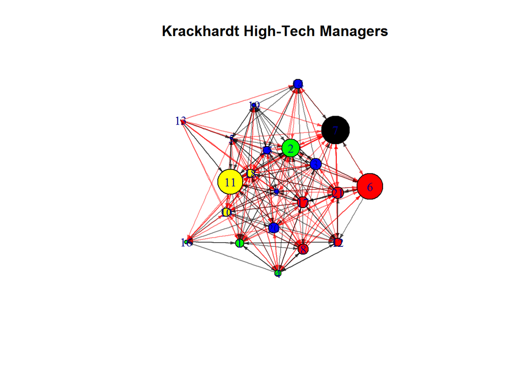

```r
plot(m, layout = layouts, main = "Krackhardt High-Tech Managers",
     vertex.color = vcolors, vertex.size = vsizes,
     edge.color = ecolors, edge.arrow.size = .3)
```

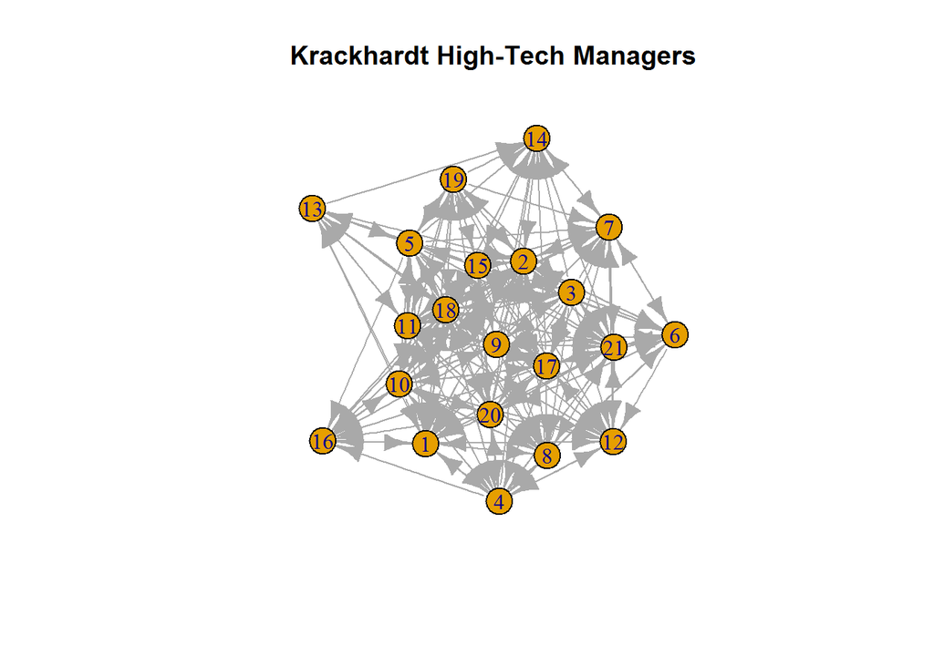

```r
plot(m, layout = layouts, main = "Krackhardt High-Tech Managers")
```

```r
#(V(m)$color <= vcolors)
#(V(m)$frame <= vcolors)
(V(m)$size <- vsizes)
```

```
##  [1]  9.333 19.583 12.750  7.500  3.333 28.000 30.000 11.333  5.417  9.250
## [11] 27.000  8.917  0.250 10.417  8.417  4.667 12.417  9.083  4.833 11.667
## [21] 12.500
```

```r
(E(m)$color <- ecolors)
```

```
##   [1] "#00000080" "#00000080" "#00000080" "#00000080" "#00000080"
##   [6] "#FF000080" "#FF000080" "#00000080" "#FF000080" "#FF000080"
##  [11] "#00000080" "#00000080" "#FF000080" "#FF000080" "#FF000080"
##  [16] "#FF000080" "#FF000080" "#FF000080" "#FF000080" "#FF000080"
##  [21] "#FF000080" "#FF000080" "#00000080" "#FF000080" "#FF000080"
##  [26] "#00000080" "#FF000080" "#FF000080" "#00000080" "#00000080"
##  [31] "#FF000080" "#00000080" "#FF000080" "#FF000080" "#00000080"
##  [36] "#00000080" "#00000080" "#FF000080" "#FF000080" "#FF000080"
##  [41] "#FF000080" "#00000080" "#FF000080" "#FF000080" "#FF000080"
##  [46] "#00000080" "#FF000080" "#00000080" "#FF000080" "#00000080"
##  [51] "#FF000080" "#00000080" "#FF000080" "#00000080" "#FF000080"
##  [56] "#00000080" "#00000080" "#00000080" "#00000080" "#00000080"
##  [61] "#00000080" "#00000080" "#FF000080" "#FF000080" "#FF000080"
##  [66] "#FF000080" "#FF000080" "#FF000080" "#FF000080" "#FF000080"
##  [71] "#FF000080" "#00000080" "#FF000080" "#FF000080" "#FF000080"
```

[output cut: 32 more lines]

```r
(E(m)$arrow.size <- .3)
```

```
## [1] 0.3
```

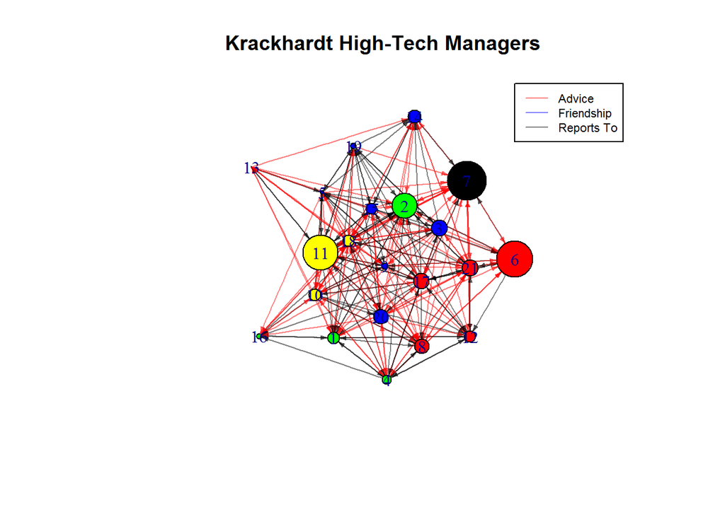

```r
plot(m, layout = layouts, main = "Krackhardt High-Tech Managers",
     vertex.color = vcolors)

legend(1, 1.25, legend = c("Advice", "Friendship", "Reports To"),   #--- 범례 표시
       col = colorStr, lty = 1, cex = .7)
```

```r
rm(colorStr)

#write.graph(m, file = "sns.txt", format = "pajek")   #--- 그래프를 파일로 저장

rm(list = c("vsizes", "ecolors"))
```

```r
library(igraph)
#--- advice_tie에 값이 있는 것만 추출
(mAdvice <- delete.edges(m, E(m)[get.edge.attribute(m, name = "advice_tie") == 0]))
```

```
## IGRAPH DN-- 21 190 --
## + attr: name (v/c), AGE (v/n), TENURE (v/n), LEVEL (v/n), DEPT
## | (v/n), size (v/n), advice_tie (e/n), friendship_tie (e/n),
## | reports_to_tie (e/n), color (e/c), arrow.size (e/n)
## + edges (vertex names):
##  [1] 1->2  1->4  1->8  1->16 1->18 1->21 2->6  2->7  2->21 3->1  3->2
## [12] 3->4  3->6  3->7  3->8  3->9  3->10 3->11 3->12 3->14 3->17 3->18
## [23] 3->20 3->21 4->1  4->2  4->6  4->8  4->10 4->11 4->12 4->16 4->17
## [34] 4->18 4->20 4->21 5->1  5->2  5->6  5->7  5->8  5->10 5->11 5->13
## [45] 5->14 5->16 5->17 5->18 5->19 5->20 5->21 6->21 7->2  7->6  7->11
## [56] 7->12 7->14 7->17 7->18 7->21 8->2  8->4  8->6  8->7  8->10 8->11
## + ... omitted several edges
```

```r
plot(mAdvice, layout = layouts, main = "Krackhardt High-Tech Managers",
     vertex.color = vcolors)

(mAdviceNo <- delete.vertices(mAdvice, V(mAdvice)[degree(mAdvice) == 0]))   #--- 다른 vertex와 연결되지 않은 vertex 삭제
```

[output not shown]

```
## IGRAPH DN-- 21 190 --
## + attr: name (v/c), AGE (v/n), TENURE (v/n), LEVEL (v/n), DEPT
## | (v/n), size (v/n), advice_tie (e/n), friendship_tie (e/n),
## | reports_to_tie (e/n), color (e/c), arrow.size (e/n)
## + edges (vertex names):
##  [1] 1->2  1->4  1->8  1->16 1->18 1->21 2->6  2->7  2->21 3->1  3->2
## [12] 3->4  3->6  3->7  3->8  3->9  3->10 3->11 3->12 3->14 3->17 3->18
## [23] 3->20 3->21 4->1  4->2  4->6  4->8  4->10 4->11 4->12 4->16 4->17
## [34] 4->18 4->20 4->21 5->1  5->2  5->6  5->7  5->8  5->10 5->11 5->13
## [45] 5->14 5->16 5->17 5->18 5->19 5->20 5->21 6->21 7->2  7->6  7->11
## [56] 7->12 7->14 7->17 7->18 7->21 8->2  8->4  8->6  8->7  8->10 8->11
## + ... omitted several edges
```

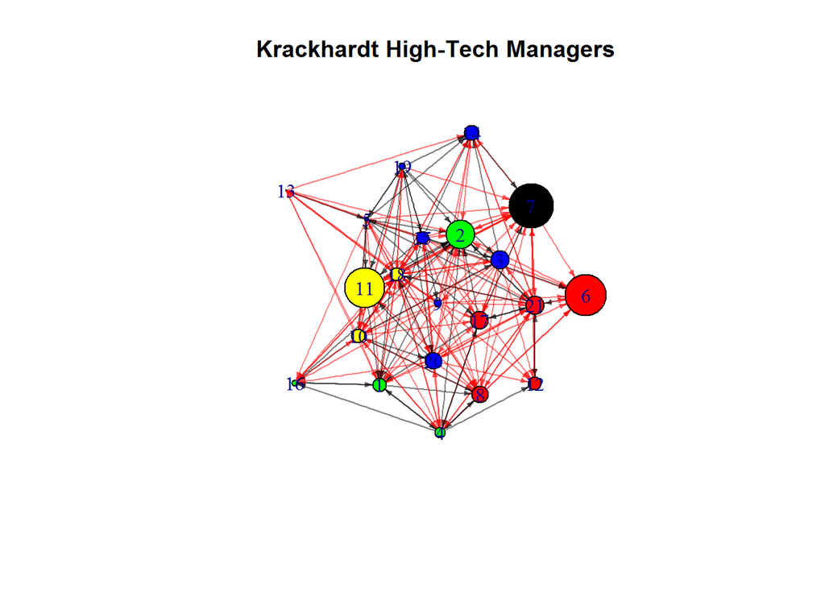

```r
plot(mAdviceNo, layout = layouts, main = "Krackhardt High-Tech Managers",
     vertex.color = vcolors)
```

```r
(mFriendship <- delete.edges(m, E(m)[get.edge.attribute(m, name = "friendship_tie") == 0]))
```

```
## IGRAPH DN-- 21 102 --
## + attr: name (v/c), AGE (v/n), TENURE (v/n), LEVEL (v/n), DEPT
## | (v/n), size (v/n), advice_tie (e/n), friendship_tie (e/n),
## | reports_to_tie (e/n), color (e/c), arrow.size (e/n)
## + edges (vertex names):
##  [1] 1 ->2  1 ->4  1 ->8  1 ->12 1 ->16 2 ->1  2 ->18 2 ->21 3 ->14 3 ->19
## [11] 4 ->1  4 ->2  4 ->8  4 ->12 4 ->16 4 ->17 5 ->2  5 ->9  5 ->11 5 ->14
## [21] 5 ->17 5 ->19 5 ->21 6 ->2  6 ->7  6 ->9  6 ->12 6 ->17 6 ->21 8 ->4
## [31] 10->3  10->5  10->8  10->9  10->12 10->16 10->20 11->1  11->2  11->3
## [41] 11->4  11->5  11->8  11->9  11->12 11->13 11->15 11->17 11->18 11->19
## [51] 12->1  12->4  12->17 12->21 13->5  13->11 14->7  14->15 15->1  15->3
## + ... omitted several edges
```

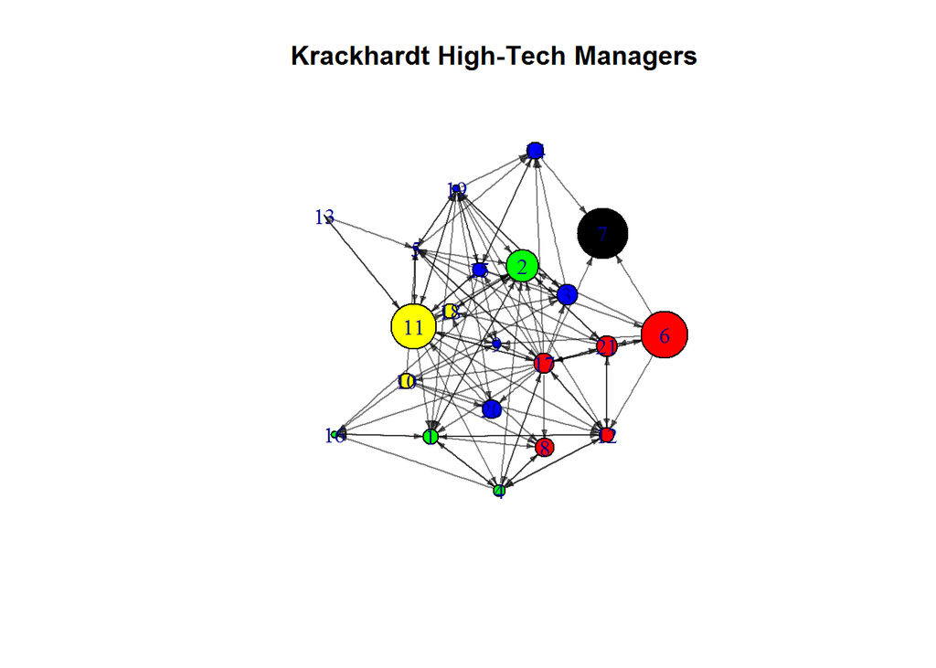

```r
plot(mFriendship, layout = layouts, main = "Krackhardt High-Tech Managers",
     vertex.color = vcolors)
```

```r
(mReport <- delete.edges(m, E(m)[get.edge.attribute(m, name = "reports_to_tie") == 0]))
```

```
## IGRAPH DN-- 21 102 --
## + attr: name (v/c), AGE (v/n), TENURE (v/n), LEVEL (v/n), DEPT
## | (v/n), size (v/n), advice_tie (e/n), friendship_tie (e/n),
## | reports_to_tie (e/n), color (e/c), arrow.size (e/n)
## + edges (vertex names):
##  [1] 1 ->2  1 ->4  1 ->8  1 ->12 1 ->16 2 ->1  2 ->18 2 ->21 3 ->14 3 ->19
## [11] 4 ->1  4 ->2  4 ->8  4 ->12 4 ->16 4 ->17 5 ->2  5 ->9  5 ->11 5 ->14
## [21] 5 ->17 5 ->19 5 ->21 6 ->2  6 ->7  6 ->9  6 ->12 6 ->17 6 ->21 8 ->4
## [31] 10->3  10->5  10->8  10->9  10->12 10->16 10->20 11->1  11->2  11->3
## [41] 11->4  11->5  11->8  11->9  11->12 11->13 11->15 11->17 11->18 11->19
## [51] 12->1  12->4  12->17 12->21 13->5  13->11 14->7  14->15 15->1  15->3
## + ... omitted several edges
```

```r
plot(mReport, layout = layouts, main = "Krackhardt High-Tech Managers",
     vertex.color = vcolors)

#rm(list = c("mAdvice", "mFriendship", "mReport", "mAdviceNo"))

###-----------------------------------------------------------------------------
#--- 매개 중심성 (Betweenness centrality) : 한 노드가 연결망 내의
#---     다른 노드들 사이의 최다 경로 위에 위치할수록 그 노드의 중심성이 높다.
(m1 <- edge.betweenness.community(m))       #--- 매개 중심성 계산
```

[output not shown]

```
## IGRAPH clustering edge betweenness, groups: 1, mod: 0
## + groups:
##   $`1`
##    [1] "1"  "2"  "3"  "4"  "5"  "6"  "7"  "8"  "9"  "10" "11" "12" "13"
##   [14] "14" "15" "16" "17" "18" "19" "20" "21"
##
```

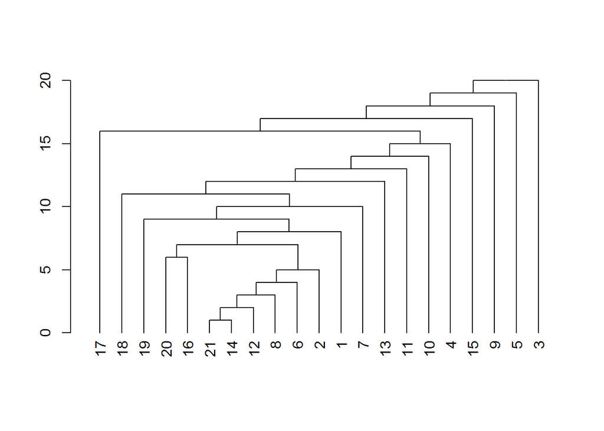

```r
plot(as.dendrogram(m1))                     #--- 계층적 군집
```

```r
rm(m1)

###-----------------------------------------------------------------------------
#--- 연결정도 중심성 (Degree centrality) : 한 점에 직접적으로 연결된 점들의 합
(deg_full_in <- degree(m, mode = "in"))     #--- indegree 계산
```

```
##  1  2  3  4  5  6  7  8  9 10 11 12 13 14 15 16 17 18 19 20 21
## 15 19  7 10  7 11 14 12  9 10 13 13  5 11  7  9 12 17  7  9 15
```

```r
(deg_full_out <- degree(m, mode = "out"))   #--- outdegree 계산
```

```
##  1  2  3  4  5  6  7  8  9 10 11 12 13 14 15 16 17 18 19 20 21
##  7  5 16 12 16  6  8  8 13 16 14  5  7  5 20  4 18 17 12 12 11
```

```r
(deg_advice_in <- degree(mAdvice, mode = "in"))
```

```
##  1  2  3  4  5  6  7  8  9 10 11 12 13 14 15 16 17 18 19 20 21
## 13 18  5  8  5 10 13 10  4  9 11  7  4 10  4  8  9 15  4  8 15
```

```r
(deg_advice_out <- degree(mAdvice, mode = "out"))
```

```
##  1  2  3  4  5  6  7  8  9 10 11 12 13 14 15 16 17 18 19 20 21
##  6  3 15 12 15  1  8  8 13 14  3  2  6  4 20  4  5 17 11 12 11
```

```r
(deg_friendship_in <- degree(mFriendship, mode = "in"))
```

```
##  1  2  3  4  5  6  7  8  9 10 11 12 13 14 15 16 17 18 19 20 21
##  8 10  5  5  6  2  3  5  6  1  6  8  1  5  4  4  6  4  5  3  5
```

```r
(deg_friendship_out <- degree(mFriendship, mode = "out"))
```

```
##  1  2  3  4  5  6  7  8  9 10 11 12 13 14 15 16 17 18 19 20 21
##  5  3  2  6  7  6  0  1  0  7 13  4  2  2  8  2 18  1  9  2  4
```

```r
(deg_reports_to_in <- degree(mReport, mode = "in"))
```

```
##  1  2  3  4  5  6  7  8  9 10 11 12 13 14 15 16 17 18 19 20 21
##  8 10  5  5  6  2  3  5  6  1  6  8  1  5  4  4  6  4  5  3  5
```

```r
(deg_reports_to_out <- degree(mReport, mode = "out"))
```

```
##  1  2  3  4  5  6  7  8  9 10 11 12 13 14 15 16 17 18 19 20 21
##  5  3  2  6  7  6  0  1  0  7 13  4  2  2  8  2 18  1  9  2  4
```

```r
###-----------------------------------------------------------------------------
#--- 근접 중심성 (Closeness centrality) : 한 노드로부터 다른 노드에 도달하기까지 필요한 최소 단계의 합
(m1 <- closeness(m))
```

```
##          1          2          3          4          5          6
## 0.03030303 0.02857143 0.04166667 0.03571429 0.04166667 0.02857143
##          7          8          9         10         11         12
## 0.03125000 0.03125000 0.03703704 0.04166667 0.03846154 0.02777778
##         13         14         15         16         17         18
## 0.03030303 0.02857143 0.05000000 0.02777778 0.04545455 0.04347826
##         19         20         21
## 0.03571429 0.03571429 0.03448276
```

```r
(m1.score <- round((m1 - min(m1)) * length(m1) / max(m1)) + 1)
```

```
##  1  2  3  4  5  6  7  8  9 10 11 12 13 14 15 16 17 18 19 20 21
##  2  1  7  4  7  1  2  2  5  7  5  1  2  1 10  1  8  8  4  4  4
```

```r
(m1.colors <- rev(heat.colors(max(m1.score))))
```

```
##  [1] "#FFFFBFFF" "#FFFF40FF" "#FFFF00FF" "#FFDB00FF" "#FFB600FF"
##  [6] "#FF9200FF" "#FF6D00FF" "#FF4900FF" "#FF2400FF" "#FF0000FF"
```

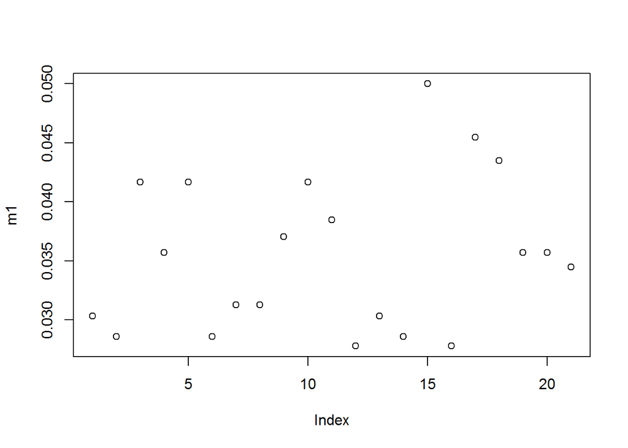

```r
plot(m1)
```

```r
rm(m1)

###-----------------------------------------------------------------------------
#--- 근접 중심성 (Closeness centrality) : 한 노드로부터 다른 노드에 도달하기까지 필요한 최소 단계의 합
(sp_full_in <- shortest.paths(m, mode = "in"))    #--- 노드간 짧은 거리 표시
```

```
##    1 2 3 4 5 6 7 8 9 10 11 12 13 14 15 16 17 18 19 20 21
## 1  0 1 1 1 1 2 2 2 1  1  1  1  1  2  1  1  1  1  1  1  2
## 2  1 0 1 1 1 1 1 1 1  1  1  2  1  1  1  1  1  1  1  1  1
## 3  2 2 0 2 2 2 2 2 2  1  1  2  2  2  1  2  1  1  1  2  1
## 4  1 2 1 0 2 2 2 1 2  1  1  1  2  2  1  2  1  1  2  2  1
## 5  2 2 2 2 0 2 2 2 2  1  1  2  1  2  1  2  1  1  1  2  2
## 6  2 1 1 1 1 0 1 1 1  2  2  2  2  2  1  2  1  2  2  1  1
## 7  2 1 1 2 1 1 0 1 1  2  1  1  2  1  1  2  1  1  1  2  1
## 8  1 2 1 1 1 2 2 0 1  1  1  2  2  2  1  2  1  1  2  1  1
## 9  2 2 1 2 1 1 2 2 0  1  1  2  1  2  1  2  1  1  2  2  2
## 10 2 2 1 1 1 2 2 1 1  0  2  2  2  2  1  1  1  1  1  2  2
## 11 2 2 1 1 1 2 1 1 1  1  0  2  1  2  1  2  1  1  1  1  2
## 12 1 2 1 1 2 1 1 2 1  1  1  0  2  2  1  2  1  2  1  1  1
## 13 2 2 2 2 1 3 2 2 2  1  1  3  0  2  1  2  2  1  2  2  2
## 14 2 2 1 2 1 2 1 2 1  2  2  2  1  0  1  2  1  1  1  1  1
## 15 2 2 2 2 2 2 2 2 2  1  1  2  2  1  0  2  1  1  1  1  2
## 16 1 2 2 1 1 2 2 2 1  1  2  2  2  2  1  0  1  1  2  1  2
## 17 2 2 1 1 1 1 1 2 1  1  1  1  2  2  1  2  0  2  2  1  1
## 18 1 1 1 1 1 2 1 1 1  1  1  2  1  1  1  1  2  0  1  1  1
## 19 2 2 1 2 1 2 2 2 2  1  1  2  2  2  1  2  1  1  0  2  2
## 20 2 2 1 1 1 2 2 2 2  1  2  2  2  2  1  2  1  1  1  0  1
## 21 1 1 1 1 1 1 1 1 1  2  2  1  2  1  1  2  1  1  2  1  0
```

```r
(sp_full_out <- shortest.paths(m, mode = "out"))   #--- 노드간 짧은 거리 표시
```

```
##    1 2 3 4 5 6 7 8 9 10 11 12 13 14 15 16 17 18 19 20 21
## 1  0 1 2 1 2 2 2 1 2  2  2  1  2  2  2  1  2  1  2  2  1
## 2  1 0 2 2 2 1 1 2 2  2  2  2  2  2  2  2  2  1  2  2  1
## 3  1 1 0 1 2 1 1 1 1  1  1  1  2  1  2  2  1  1  1  1  1
## 4  1 1 2 0 2 1 2 1 2  1  1  1  2  2  2  1  1  1  2  1  1
## 5  1 1 2 2 0 1 1 1 1  1  1  2  1  1  2  1  1  1  1  1  1
## 6  2 1 2 2 2 0 1 2 1  2  2  1  3  2  2  2  1  2  2  2  1
## 7  2 1 2 2 2 1 0 2 2  2  1  1  2  1  2  2  1  1  2  2  1
## 8  2 1 2 1 2 1 1 0 2  1  1  2  2  2  2  2  2  1  2  2  1
## 9  1 1 2 2 2 1 1 1 0  1  1  1  2  1  2  1  1  1  2  2  1
## 10 1 1 1 1 1 2 2 1 1  0  1  1  1  2  1  1  1  1  1  1  2
## 11 1 1 1 1 1 2 1 1 1  2  0  1  1  2  1  2  1  1  1  2  2
## 12 1 2 2 1 2 2 1 2 2  2  2  0  3  2  2  2  1  2  2  2  1
## 13 1 1 2 2 1 2 2 2 1  2  1  2  0  1  2  2  2  1  2  2  2
## 14 2 1 2 2 2 2 1 2 2  2  2  2  2  0  1  2  2  1  2  2  1
## 15 1 1 1 1 1 1 1 1 1  1  1  1  1  1  0  1  1  1  1  1  1
## 16 1 1 2 2 2 2 2 2 2  1  2  2  2  2  2  0  2  1  2  2  2
## 17 1 1 1 1 1 1 1 1 1  1  1  1  2  1  1  1  0  2  1  1  1
## 18 1 1 1 1 1 2 1 1 1  1  1  2  1  1  1  1  2  0  1  1  1
## 19 1 1 1 2 1 2 1 2 2  1  1  1  2  1  1  2  2  1  0  1  2
## 20 1 1 2 2 2 1 2 1 2  2  1  1  2  1  1  1  1  1  2  0  1
## 21 2 1 1 1 2 1 1 1 2  2  2  1  2  1  2  2  1  1  2  1  0
```

```r
(sp_advice_in <- shortest.paths(mAdvice, mode = "in"))
```

```
##    1 2 3 4 5 6 7 8 9 10 11 12 13 14 15 16 17 18 19 20 21
## 1  0 3 1 1 1 3 2 2 1  1  1  3  1  2  1  1  1  1  1  1  2
## 2  1 0 1 1 1 2 1 1 1  1  1  2  1  1  1  1  1  1  1  1  1
## 3  2 2 0 2 2 2 2 2 2  1  3  2  2  2  1  2  2  1  1  2  1
## 4  1 2 1 0 2 2 2 1 2  1  2  2  2  2  1  2  1  1  2  2  1
## 5  2 3 2 2 0 3 2 2 2  1  3  3  1  2  1  2  3  1  1  2  2
## 6  2 1 1 1 1 0 1 1 1  2  2  2  2  2  1  2  2  2  2  1  1
## 7  2 1 1 2 1 2 0 1 1  2  1  1  2  1  1  2  1  1  1  2  1
## 8  1 2 1 1 1 2 2 0 1  1  2  2  2  2  1  2  2  1  2  1  1
## 9  2 3 1 2 2 3 2 2 0  2  3  3  1  2  1  2  3  1  2  2  2
## 10 2 3 1 1 1 3 2 1 1  0  3  3  2  2  1  1  2  1  1  2  2
## 11 2 2 1 1 1 3 1 1 1  1  0  2  2  2  1  2  2  1  1  1  2
## 12 2 2 1 1 2 2 1 2 1  2  2  0  2  2  1  3  2  2  2  1  1
## 13 2 3 2 2 1 3 2 2 2  1  3  3  0  2  1  2  3  1  2  2  2
## 14 2 2 1 2 1 2 1 2 1  2  2  2  1  0  1  2  2  1  1  1  1
## 15 2 3 2 2 2 3 2 2 2  1  3  3  2  2  0  2  3  1  1  1  2
## 16 1 3 2 1 1 3 2 2 1  1  2  3  2  2  1  0  2  1  2  1  2
## 17 2 2 1 1 1 2 1 2 1  1  2  2  2  2  1  2  0  2  2  1  1
## 18 1 2 1 1 1 2 1 1 1  1  2  2  1  1  1  1  2  0  1  1  1
## 19 2 3 2 2 1 3 2 2 2  1  3  3  2  2  1  2  3  1  0  2  2
## 20 2 2 1 1 1 2 2 2 2  1  3  2  2  2  1  2  2  1  1  0  1
## 21 1 1 1 1 1 1 1 1 1  2  2  1  2  1  1  2  1  1  2  1  0
```

```r
(sp_advice_out <- shortest.paths(mAdvice, mode = "out"))
```

```
##    1 2 3 4 5 6 7 8 9 10 11 12 13 14 15 16 17 18 19 20 21
## 1  0 1 2 1 2 2 2 1 2  2  2  2  2  2  2  1  2  1  2  2  1
## 2  3 0 2 2 3 1 1 2 3  3  2  2  3  2  3  3  2  2  3  2  1
## 3  1 1 0 1 2 1 1 1 1  1  1  1  2  1  2  2  1  1  2  1  1
## 4  1 1 2 0 2 1 2 1 2  1  1  1  2  2  2  1  1  1  2  1  1
## 5  1 1 2 2 0 1 1 1 2  1  1  2  1  1  2  1  1  1  1  1  1
## 6  3 2 2 2 3 0 2 2 3  3  3  2  3  2  3  3  2  2  3  2  1
## 7  2 1 2 2 2 1 0 2 2  2  1  1  2  1  2  2  1  1  2  2  1
## 8  2 1 2 1 2 1 1 0 2  1  1  2  2  2  2  2  2  1  2  2  1
## 9  1 1 2 2 2 1 1 1 0  1  1  1  2  1  2  1  1  1  2  2  1
## 10 1 1 1 1 1 2 2 1 2  0  1  2  1  2  1  1  1  1  1  1  2
## 11 1 1 3 2 3 2 1 2 3  3  0  2  3  2  3  2  2  2  3  3  2
## 12 3 2 2 2 3 2 1 2 3  3  2  0  3  2  3  3  2  2  3  2  1
## 13 1 1 2 2 1 2 2 2 1  2  2  2  0  1  2  2  2  1  2  2  2
## 14 2 1 2 2 2 2 1 2 2  2  2  2  2  0  2  2  2  1  2  2  1
## 15 1 1 1 1 1 1 1 1 1  1  1  1  1  1  0  1  1  1  1  1  1
## 16 1 1 2 2 2 2 2 2 2  1  2  3  2  2  2  0  2  1  2  2  2
## 17 1 1 2 1 3 2 1 2 3  2  2  2  3  2  3  2  0  2  3  2  1
## 18 1 1 1 1 1 2 1 1 1  1  1  2  1  1  1  1  2  0  1  1  1
## 19 1 1 1 2 1 2 1 2 2  1  1  2  2  1  1  2  2  1  0  1  2
## 20 1 1 2 2 2 1 2 1 2  2  1  1  2  1  1  1  1  1  2  0  1
## 21 2 1 1 1 2 1 1 1 2  2  2  1  2  1  2  2  1  1  2  1  0
```

```r
(sp_friendship_in <- shortest.paths(mFriendship, mode = "in"))
```

```
##    1 2 3 4 5 6   7 8   9 10 11 12 13 14 15 16 17 18 19 20 21
## 1  0 1 2 1 2 2 Inf 2 Inf  2  1  1  2  2  1  1  1  2  1  2  2
## 2  1 0 2 1 1 1 Inf 2 Inf  2  1  2  2  3  2  1  1  1  1  2  1
## 3  3 3 0 2 2 2 Inf 3 Inf  1  1  2  2  2  1  4  1  4  1  2  2
## 4  1 2 3 0 2 2 Inf 1 Inf  2  1  1  2  3  2  2  1  3  2  2  2
## 5  3 3 2 2 0 2 Inf 3 Inf  1  1  2  1  2  1  4  1  4  1  2  2
## 6  3 3 3 2 2 0 Inf 3 Inf  3  2  2  3  2  1  4  1  4  2  3  2
## 7  3 3 2 2 2 1   0 3 Inf  3  2  2  3  1  2  4  1  4  2  3  2
## 8  1 2 3 1 2 2 Inf 0 Inf  1  1  2  2  3  2  2  1  3  2  2  2
## 9  3 3 3 2 1 1 Inf 3   0  1  1  2  2  2  1  4  1  4  2  2  2
## 10 3 3 4 2 2 2 Inf 3 Inf  0  2  2  3  4  3  4  1  4  3  3  2
## 11 3 3 2 2 1 2 Inf 3 Inf  2  0  2  1  2  1  4  1  4  1  1  2
## 12 1 2 2 1 2 1 Inf 2 Inf  1  1  0  2  3  2  2  1  3  1  2  1
## 13 4 4 3 3 2 3 Inf 4 Inf  3  1  3  0  3  2  5  2  5  2  2  3
## 14 3 3 1 2 1 2 Inf 3 Inf  2  2  2  2  0  1  4  1  4  1  3  2
## 15 3 3 2 2 2 2 Inf 3 Inf  3  1  2  2  1  0  4  1  4  1  2  2
## 16 1 2 3 1 2 2 Inf 2 Inf  1  2  2  3  3  2  0  1  3  2  3  2
## 17 2 2 3 1 1 1 Inf 2 Inf  2  1  1  2  3  2  3  0  3  2  2  1
## 18 2 1 3 2 2 2 Inf 3 Inf  2  1  2  2  3  2  2  2  0  2  1  1
## 19 3 3 1 2 1 2 Inf 3 Inf  2  1  2  2  2  1  4  1  4  0  2  2
## 20 3 3 2 2 2 2 Inf 3 Inf  1  2  2  3  3  2  4  1  4  1  0  2
## 21 2 1 3 2 1 1 Inf 3 Inf  2  2  1  2  3  2  2  1  2  2  3  0
```

```r
(sp_friendship_out <- shortest.paths(mFriendship, mode = "out"))
```

```
##      1   2   3   4   5   6   7   8   9  10  11  12  13  14  15  16  17  18
## 1    0   1   3   1   3   3   3   1   3   3   3   1   4   3   3   1   2   2
## 2    1   0   3   2   3   3   3   2   3   3   3   2   4   3   3   2   2   1
## 3    2   2   0   3   2   3   2   3   3   4   2   2   3   1   2   3   3   3
## 4    1   1   2   0   2   2   2   1   2   2   2   1   3   2   2   1   1   2
## 5    2   1   2   2   0   2   2   2   1   2   1   2   2   1   2   2   1   2
## 6    2   1   2   2   2   0   1   2   1   2   2   1   3   2   2   2   1   2
## 7  Inf Inf Inf Inf Inf Inf   0 Inf Inf Inf Inf Inf Inf Inf Inf Inf Inf Inf
## 8    2   2   3   1   3   3   3   0   3   3   3   2   4   3   3   2   2   3
## 9  Inf Inf Inf Inf Inf Inf Inf Inf   0 Inf Inf Inf Inf Inf Inf Inf Inf Inf
## 10   2   2   1   2   1   3   3   1   1   0   2   1   3   2   3   1   2   2
## 11   1   1   1   1   1   2   2   1   1   2   0   1   1   2   1   2   1   1
## 12   1   2   2   1   2   2   2   2   2   2   2   0   3   2   2   2   1   2
## 13   2   2   2   2   1   3   3   2   2   3   1   2   0   2   2   3   2   2
## 14   2   3   2   3   2   2   1   3   2   4   2   3   3   0   1   3   3   3
```

[output cut: 29 more lines]

```r
(sp_reports_to_in <- shortest.paths(mReport, mode = "in"))
```

```
##    1 2 3 4 5 6   7 8   9 10 11 12 13 14 15 16 17 18 19 20 21
## 1  0 1 2 1 2 2 Inf 2 Inf  2  1  1  2  2  1  1  1  2  1  2  2
## 2  1 0 2 1 1 1 Inf 2 Inf  2  1  2  2  3  2  1  1  1  1  2  1
## 3  3 3 0 2 2 2 Inf 3 Inf  1  1  2  2  2  1  4  1  4  1  2  2
## 4  1 2 3 0 2 2 Inf 1 Inf  2  1  1  2  3  2  2  1  3  2  2  2
## 5  3 3 2 2 0 2 Inf 3 Inf  1  1  2  1  2  1  4  1  4  1  2  2
## 6  3 3 3 2 2 0 Inf 3 Inf  3  2  2  3  2  1  4  1  4  2  3  2
## 7  3 3 2 2 2 1   0 3 Inf  3  2  2  3  1  2  4  1  4  2  3  2
## 8  1 2 3 1 2 2 Inf 0 Inf  1  1  2  2  3  2  2  1  3  2  2  2
## 9  3 3 3 2 1 1 Inf 3   0  1  1  2  2  2  1  4  1  4  2  2  2
## 10 3 3 4 2 2 2 Inf 3 Inf  0  2  2  3  4  3  4  1  4  3  3  2
## 11 3 3 2 2 1 2 Inf 3 Inf  2  0  2  1  2  1  4  1  4  1  1  2
## 12 1 2 2 1 2 1 Inf 2 Inf  1  1  0  2  3  2  2  1  3  1  2  1
## 13 4 4 3 3 2 3 Inf 4 Inf  3  1  3  0  3  2  5  2  5  2  2  3
## 14 3 3 1 2 1 2 Inf 3 Inf  2  2  2  2  0  1  4  1  4  1  3  2
## 15 3 3 2 2 2 2 Inf 3 Inf  3  1  2  2  1  0  4  1  4  1  2  2
## 16 1 2 3 1 2 2 Inf 2 Inf  1  2  2  3  3  2  0  1  3  2  3  2
## 17 2 2 3 1 1 1 Inf 2 Inf  2  1  1  2  3  2  3  0  3  2  2  1
## 18 2 1 3 2 2 2 Inf 3 Inf  2  1  2  2  3  2  2  2  0  2  1  1
## 19 3 3 1 2 1 2 Inf 3 Inf  2  1  2  2  2  1  4  1  4  0  2  2
## 20 3 3 2 2 2 2 Inf 3 Inf  1  2  2  3  3  2  4  1  4  1  0  2
## 21 2 1 3 2 1 1 Inf 3 Inf  2  2  1  2  3  2  2  1  2  2  3  0
```

```r
(sp_reports_to_out <- shortest.paths(mReport, mode = "out"))
```

```
##      1   2   3   4   5   6   7   8   9  10  11  12  13  14  15  16  17  18
## 1    0   1   3   1   3   3   3   1   3   3   3   1   4   3   3   1   2   2
## 2    1   0   3   2   3   3   3   2   3   3   3   2   4   3   3   2   2   1
## 3    2   2   0   3   2   3   2   3   3   4   2   2   3   1   2   3   3   3
## 4    1   1   2   0   2   2   2   1   2   2   2   1   3   2   2   1   1   2
## 5    2   1   2   2   0   2   2   2   1   2   1   2   2   1   2   2   1   2
## 6    2   1   2   2   2   0   1   2   1   2   2   1   3   2   2   2   1   2
## 7  Inf Inf Inf Inf Inf Inf   0 Inf Inf Inf Inf Inf Inf Inf Inf Inf Inf Inf
## 8    2   2   3   1   3   3   3   0   3   3   3   2   4   3   3   2   2   3
## 9  Inf Inf Inf Inf Inf Inf Inf Inf   0 Inf Inf Inf Inf Inf Inf Inf Inf Inf
## 10   2   2   1   2   1   3   3   1   1   0   2   1   3   2   3   1   2   2
## 11   1   1   1   1   1   2   2   1   1   2   0   1   1   2   1   2   1   1
## 12   1   2   2   1   2   2   2   2   2   2   2   0   3   2   2   2   1   2
## 13   2   2   2   2   1   3   3   2   2   3   1   2   0   2   2   3   2   2
## 14   2   3   2   3   2   2   1   3   2   4   2   3   3   0   1   3   3   3
```

[output cut: 29 more lines]

```r
###-----------------------------------------------------------------------------
#--- matrix에서 행 vertex에서 열 vertex로 연결이 있으면 1을 설정
reachability <- function(m, mode) {
  reach_mat <- matrix(nrow = vcount(m), ncol = vcount(m))
  for (idx in 1:vcount(m)) {
    reach_mat[idx, ] <- 0
    #    reaches <- subcomponent(m, idx, mode = mode)   #--- 특정 vertex와 연결된 버텍스 집합을 반환
    reaches <- subcomponent(m, idx, mode = mode)[2:(degree(m, mode = mode)[idx] + 1)]
    for (pos in 1:(length(reaches))) {
      reach_mat[idx, reaches[pos]] <- 1
    }
  }
  return(reach_mat)
}
(reach_full_in <- reachability(m, "in"))
```

```
##       [,1] [,2] [,3] [,4] [,5] [,6] [,7] [,8] [,9] [,10] [,11] [,12] [,13]
##  [1,]    0    1    1    1    1    0    0    0    1     1     1     1     1
##  [2,]    1    0    1    1    1    1    1    1    1     1     1     0     1
##  [3,]    0    0    0    0    0    0    0    0    0     1     1     0     0
##  [4,]    1    0    1    0    0    0    0    1    0     1     1     1     0
##  [5,]    0    0    0    0    0    0    0    0    0     1     1     0     1
##  [6,]    0    1    1    1    1    0    1    1    1     0     0     0     0
##  [7,]    0    1    1    0    1    1    0    1    1     0     1     1     0
##  [8,]    1    0    1    1    1    0    0    0    1     1     1     0     0
##  [9,]    0    0    1    0    1    1    0    0    0     1     1     0     1
## [10,]    0    0    1    1    1    0    0    1    1     0     0     0     0
## [11,]    0    0    1    1    1    0    1    1    1     1     0     0     1
## [12,]    1    0    1    1    0    1    1    0    1     1     1     0     0
## [13,]    0    0    0    0    1    0    0    0    0     1     1     0     0
## [14,]    0    0    1    0    1    0    1    0    1     0     0     0     1
```

[output cut: 29 more lines]

```r
(reach_full_out <- reachability(m, "out"))
```

```
##       [,1] [,2] [,3] [,4] [,5] [,6] [,7] [,8] [,9] [,10] [,11] [,12] [,13]
##  [1,]    0    1    0    1    0    0    0    1    0     0     0     1     0
##  [2,]    1    0    0    0    0    1    1    0    0     0     0     0     0
##  [3,]    1    1    0    1    0    1    1    1    1     1     1     1     0
##  [4,]    1    1    0    0    0    1    0    1    0     1     1     1     0
##  [5,]    1    1    0    0    0    1    1    1    1     1     1     0     1
##  [6,]    0    1    0    0    0    0    1    0    1     0     0     1     0
##  [7,]    0    1    0    0    0    1    0    0    0     0     1     1     0
##  [8,]    0    1    0    1    0    1    1    0    0     1     1     0     0
##  [9,]    1    1    0    0    0    1    1    1    0     1     1     1     0
## [10,]    1    1    1    1    1    0    0    1    1     0     1     1     1
## [11,]    1    1    1    1    1    0    1    1    1     0     0     1     1
## [12,]    1    0    0    1    0    0    1    0    0     0     0     0     0
## [13,]    1    1    0    0    1    0    0    0    1     0     1     0     0
## [14,]    0    1    0    0    0    0    1    0    0     0     0     0     0
```

[output cut: 29 more lines]

```r
(reach_advice_in <- reachability(mAdvice, "in"))
```

```
##       [,1] [,2] [,3] [,4] [,5] [,6] [,7] [,8] [,9] [,10] [,11] [,12] [,13]
##  [1,]    0    0    1    1    1    0    0    0    1     1     1     0     1
##  [2,]    1    0    1    1    1    0    1    1    1     1     1     0     1
##  [3,]    0    0    0    0    0    0    0    0    0     1     0     0     0
##  [4,]    1    0    1    0    0    0    0    1    0     1     0     0     0
##  [5,]    0    0    0    0    0    0    0    0    0     1     0     0     1
##  [6,]    0    1    1    1    1    0    1    1    1     0     0     0     0
##  [7,]    0    1    1    0    1    0    0    1    1     0     1     1     0
##  [8,]    1    0    1    1    1    0    0    0    1     1     0     0     0
##  [9,]    0    0    1    0    0    0    0    0    0     0     0     0     1
## [10,]    0    0    1    1    1    0    0    1    1     0     0     0     0
## [11,]    0    0    1    1    1    0    1    1    1     1     0     0     0
## [12,]    0    0    1    1    0    0    1    0    1     0     0     0     0
## [13,]    0    0    0    0    1    0    0    0    0     1     0     0     0
## [14,]    0    0    1    0    1    0    1    0    1     0     0     0     1
```

[output cut: 29 more lines]

```r
(reach_advice_out <- reachability(mAdvice, "out"))
```

```
##       [,1] [,2] [,3] [,4] [,5] [,6] [,7] [,8] [,9] [,10] [,11] [,12] [,13]
##  [1,]    0    1    0    1    0    0    0    1    0     0     0     0     0
##  [2,]    0    0    0    0    0    1    1    0    0     0     0     0     0
##  [3,]    1    1    0    1    0    1    1    1    1     1     1     1     0
##  [4,]    1    1    0    0    0    1    0    1    0     1     1     1     0
##  [5,]    1    1    0    0    0    1    1    1    0     1     1     0     1
##  [6,]    0    0    0    0    0    0    0    0    0     0     0     0     0
##  [7,]    0    1    0    0    0    1    0    0    0     0     1     1     0
##  [8,]    0    1    0    1    0    1    1    0    0     1     1     0     0
##  [9,]    1    1    0    0    0    1    1    1    0     1     1     1     0
## [10,]    1    1    1    1    1    0    0    1    0     0     1     0     1
## [11,]    1    1    0    0    0    0    1    0    0     0     0     0     0
## [12,]    0    0    0    0    0    0    1    0    0     0     0     0     0
## [13,]    1    1    0    0    1    0    0    0    1     0     0     0     0
## [14,]    0    1    0    0    0    0    1    0    0     0     0     0     0
```

[output cut: 29 more lines]

```r
(reach_friendship_in <- reachability(mFriendship, "in"))
```

```
##       [,1] [,2] [,3] [,4] [,5] [,6] [,7] [,8] [,9] [,10] [,11] [,12] [,13]
##  [1,]    0    1    0    1    0    0    0    0    0     0     1     1     0
##  [2,]    1    0    0    1    1    1    0    0    0     0     1     0     0
##  [3,]    0    0    0    0    0    0    0    0    0     1     1     0     0
##  [4,]    1    0    0    0    0    0    0    1    0     0     1     1     0
##  [5,]    0    0    0    0    0    0    0    0    0     1     1     0     1
##  [6,]    0    0    0    0    0    0    0    0    0     0     0     0     0
##  [7,]    0    0    0    0    0    1    0    0    0     0     0     0     0
##  [8,]    1    0    0    1    0    0    0    0    0     1     1     0     0
##  [9,]    0    0    0    0    1    1    0    0    0     1     1     0     0
## [10,]    0    0    0    0    0    0    0    0    0     0     0     0     0
## [11,]    0    0    0    0    1    0    0    0    0     0     0     0     1
## [12,]    1    0    0    1    0    1    0    0    0     1     1     0     0
## [13,]    0    0    0    0    0    0    0    0    0     0     1     0     0
## [14,]    0    0    1    0    1    0    0    0    0     0     0     0     0
```

[output cut: 29 more lines]

```r
#(reach_friendship_out <- reachability(mFriendship, "out"))
(reach_reports_to_in <- reachability(mReport, "in"))
```

```
##       [,1] [,2] [,3] [,4] [,5] [,6] [,7] [,8] [,9] [,10] [,11] [,12] [,13]
##  [1,]    0    1    0    1    0    0    0    0    0     0     1     1     0
##  [2,]    1    0    0    1    1    1    0    0    0     0     1     0     0
##  [3,]    0    0    0    0    0    0    0    0    0     1     1     0     0
##  [4,]    1    0    0    0    0    0    0    1    0     0     1     1     0
##  [5,]    0    0    0    0    0    0    0    0    0     1     1     0     1
##  [6,]    0    0    0    0    0    0    0    0    0     0     0     0     0
##  [7,]    0    0    0    0    0    1    0    0    0     0     0     0     0
##  [8,]    1    0    0    1    0    0    0    0    0     1     1     0     0
##  [9,]    0    0    0    0    1    1    0    0    0     1     1     0     0
## [10,]    0    0    0    0    0    0    0    0    0     0     0     0     0
## [11,]    0    0    0    0    1    0    0    0    0     0     0     0     1
## [12,]    1    0    0    1    0    1    0    0    0     1     1     0     0
## [13,]    0    0    0    0    0    0    0    0    0     0     1     0     0
## [14,]    0    0    1    0    1    0    0    0    0     0     0     0     0
```

[output cut: 29 more lines]

```r
#(reach_reports_to_out <- reachability(mReport, "out"))
```

```r
###-----------------------------------------------------------------------------
#--- 각 노드의 통계를 데이터프레임으로 만들어 csv 포맷으로 저장
reach_full_in_vec <- vector()           #--- in 접속 평균
reach_full_out_vec <- vector()          #--- out 접속 평균
reach_advice_in_vec <- vector()
reach_advice_out_vec <- vector()
reach_friendship_in_vec <- vector()
reach_friendship_out_vec <- vector()
reach_reports_to_in_vec <- vector()
reach_reports_to_out_vec <- vector()

sp_full_in_vec <- vector()              #--- in 근접 중심성 평균
sp_full_out_vec <- vector()             #--- out 근접 중심성 평균
sp_advice_in_vec <- vector()
sp_advice_out_vec <- vector()
sp_friendship_in_vec <- vector()
sp_friendship_out_vec <- vector()
sp_reports_to_in_vec <- vector()
sp_reports_to_out_vec <- vector()

for (i in 1:vcount(m)) {
  reach_full_in_vec[i] <- mean(reach_full_in[i,])
  reach_full_out_vec[i] <- mean(reach_full_out[i,])
  reach_advice_in_vec[i] <- mean(reach_advice_in[i,])
  reach_advice_out_vec[i] <- mean(reach_advice_out[i,])
  reach_friendship_in_vec[i] <- mean(reach_friendship_in[i,])
 # reach_friendship_out_vec[i] <- mean(reach_friendship_out[i,])
  reach_reports_to_in_vec[i] <- mean(reach_reports_to_in[i,])
#  reach_reports_to_out_vec[i] <- mean(reach_reports_to_out[i,])

  sp_full_in_vec[i] <- mean(sp_full_in[i,])
  sp_full_out_vec[i] <- mean(sp_full_out[i,])
  sp_advice_in_vec[i] <- mean(sp_advice_in[i,])
  sp_advice_out_vec[i] <- mean(sp_advice_out[i,])
  sp_friendship_in_vec[i] <- mean(sp_friendship_in[i,])
 # sp_friendship_out_vec[i] <- mean(sp_friendship_out[i,])
  sp_reports_to_in_vec[i] <- mean(sp_reports_to_in[i,])
#  sp_reports_to_out_vec[i] <- mean(sp_reports_to_out[i,])
}
reach_full_in_vec
```

```
##  [1] 0.7142857 0.9047619 0.3333333 0.4761905 0.3333333 0.5238095 0.6666667
##  [8] 0.5714286 0.4285714 0.4761905 0.6190476 0.6190476 0.2380952 0.5238095
## [15] 0.3333333 0.4285714 0.5714286 0.8095238 0.3333333 0.4285714 0.7142857
```

```r
reach_full_out_vec
```

```
##  [1] 0.3333333 0.2380952 0.7619048 0.5714286 0.7619048 0.2857143 0.3809524
##  [8] 0.3809524 0.6190476 0.7619048 0.6666667 0.2380952 0.3333333 0.2380952
## [15] 0.9523810 0.1904762 0.8571429 0.8095238 0.5714286 0.5714286 0.5238095
```

```r
sp_full_in_vec
```

```
##  [1] 1.190476 1.000000 1.571429 1.428571 1.571429 1.380952 1.238095
##  [8] 1.333333 1.476190 1.428571 1.285714 1.285714 1.761905 1.380952
## [15] 1.571429 1.476190 1.333333 1.095238 1.571429 1.476190 1.190476
```

```r
sp_full_out_vec
```

```
##  [1] 1.571429 1.666667 1.142857 1.333333 1.142857 1.666667 1.523810
##  [8] 1.523810 1.285714 1.142857 1.238095 1.714286 1.571429 1.666667
## [15] 0.952381 1.714286 1.047619 1.095238 1.333333 1.333333 1.380952
```

```r
(node_stats_df <- cbind(
  deg_full_in, deg_full_out,
  deg_advice_in, deg_advice_out,
  deg_friendship_in, deg_friendship_out,
  deg_reports_to_in, deg_reports_to_out,

  reach_full_in_vec, reach_full_out_vec,
  reach_advice_in_vec, reach_advice_out_vec,
  reach_friendship_in_vec, reach_friendship_out_vec,
  reach_reports_to_in_vec, reach_reports_to_out_vec,

  sp_full_in_vec, sp_full_out_vec,
  sp_advice_in_vec, sp_advice_out_vec,
  sp_friendship_in_vec, sp_friendship_out_vec,
  sp_reports_to_in_vec, sp_reports_to_out_vec
))
```

```
##    deg_full_in deg_full_out deg_advice_in deg_advice_out deg_friendship_in
## 1           15            7            13              6                 8
## 2           19            5            18              3                10
## 3            7           16             5             15                 5
## 4           10           12             8             12                 5
## 5            7           16             5             15                 6
## 6           11            6            10              1                 2
## 7           14            8            13              8                 3
## 8           12            8            10              8                 5
## 9            9           13             4             13                 6
## 10          10           16             9             14                 1
## 11          13           14            11              3                 6
## 12          13            5             7              2                 8
## 13           5            7             4              6                 1
## 14          11            5            10              4                 5
```

[output cut: 117 more lines]

```r
###-----------------------------------------------------------------------------
#--- 그래프 분석시 통계량
#--- 연결정도 중심성 : Degree         : mean(deg_full_in), sd(deg_full_in)
#--- 근접 중심성     : Shortest paths : mean(sp_full_in[which(sp_full_in != Inf)]), sd(~)
#--- 도달 가능성 : Reachability : mean(reach_full_in[which_reach_full_in != Inf]), sd(~)
#--- ? 밀도 : Density : graph.density(m)
#--- ? 상호관계 : Reciprocity : reciprocity(m)
#--- ? 이행 : Transitivity : transitivity(m)
#--- ? triad.census(m)


#--- Triad census
#--- 라벨 표시
census_labels <- c("003", "012", "102", "021D", "021U",
                   "021C", "111D", "111U", "030T", "030C",
                   "201", "120D", "120U", "120C", "210",
                   "300")
(tc_full <- triad.census(m))
```

```
##  [1]  29  99  93  90  57  28  72 130 121   0 121  77  98  31 208  76
```

```r
(tc_advice <- triad.census(mAdvice))
```

```
##  [1]  74 153  90 160  86  49  59 101 190   2  72  62  78  17 107  30
```

```r
(tc_friendship <- triad.census(mFriendship))
```

```
##  [1] 376 366 143 114  34  35  39 101  23   0  20  16  25   9  23   6
```

```r
(tc_reports_to <- triad.census(mReport))
```

```
##  [1] 376 366 143 114  34  35  39 101  23   0  20  16  25   9  23   6
```

```r
(triad_df <- data.frame(census_labels, tc_full, tc_advice, tc_friendship, tc_reports_to))
```

```
##    census_labels tc_full tc_advice tc_friendship tc_reports_to
## 1            003      29        74           376           376
## 2            012      99       153           366           366
## 3            102      93        90           143           143
## 4           021D      90       160           114           114
## 5           021U      57        86            34            34
## 6           021C      28        49            35            35
## 7           111D      72        59            39            39
## 8           111U     130       101           101           101
## 9           030T     121       190            23            23
## 10          030C       0         2             0             0
## 11           201     121        72            20            20
## 12          120D      77        62            16            16
## 13          120U      98        78            25            25
## 14          120C      31        17             9             9
## 15           210     208       107            23            23
## 16           300      76        30             6             6
```

```r
#write.csv(triad_df, "krack_triads.csv")



###-----------------------------------------------------------------------------
data(studentnets.M182, package = "NetData")
library(igraph)
(data <- subset(m182_full_data_frame, (friend_tie > 0 | social_tie > 0 | task_tie > 0)))
```

```
##     ego alter friend_tie social_tie task_tie
## 5     1     5          0       1.20     0.30
## 8     1     8          0       0.15     0.00
## 9     1     9          0       2.85     0.30
## 10    1    10          0       6.45     0.30
## 11    1    11          0       0.30     0.00
## 12    1    12          0       1.95     0.15
## 13    1    13          0       0.60     0.00
## 15    1    15          0       5.10     0.15
## 16    1    16          0       1.35     5.10
## 17    2     1          1       0.00     0.00
## 19    2     3          0       0.15     0.00
## 23    2     7          1       2.25     0.75
## 24    2     8          1       3.90     0.30
## 28    2    12          0       0.30     0.00
```

[output cut: 130 more lines]

```r
(m <- graph.data.frame(data))
```

```
## IGRAPH DN-- 16 144 --
## + attr: name (v/c), friend_tie (e/n), social_tie (e/n), task_tie
## | (e/n)
## + edges (vertex names):
##  [1] 1->5  1->8  1->9  1->10 1->11 1->12 1->13 1->15 1->16 2->1  2->3
## [12] 2->7  2->8  2->12 2->13 2->14 2->15 2->16 3->2  3->5  3->6  3->7
## [23] 3->8  3->10 3->11 3->14 3->15 3->16 4->10 4->16 5->1  5->3  5->6
## [34] 5->8  5->10 5->11 5->13 5->15 5->16 6->1  6->3  6->5  6->7  6->8
## [45] 6->10 6->11 6->12 6->14 6->16 7->2  7->3  7->8  7->13 7->14 7->15
## [56] 7->16 8->2  8->3  8->5  8->6  8->7  8->11 8->13 8->14 8->15 8->16
## [67] 9->1  9->3  9->10 9->12 9->15 9->16
## + ... omitted several edges
```

```r
rm(list = c("m182_full_data_frame", "friend_df", "social_df", "task_df"))

summary(m)
```

```
## IGRAPH DN-- 16 144 --
## + attr: name (v/c), friend_tie (e/n), social_tie (e/n), task_tie
## | (e/n)
```

```r
vcount(m)                               #--- Vertex 개수
```

```
## [1] 16
```

```r
V(m)                                    #--- Vertex
```

```
## + 16/16 vertices, named:
##  [1] 1  2  3  4  5  6  7  8  9  10 11 12 13 14 15 16
```

```r
ecount(m)                               #--- Edge 개수
```

```
## [1] 144
```

```r
E(m)                                    #--- Edge
```

```
## + 144/144 edges (vertex names):
##   [1] 1 ->5  1 ->8  1 ->9  1 ->10 1 ->11 1 ->12 1 ->13 1 ->15 1 ->16 2 ->1
##  [11] 2 ->3  2 ->7  2 ->8  2 ->12 2 ->13 2 ->14 2 ->15 2 ->16 3 ->2  3 ->5
##  [21] 3 ->6  3 ->7  3 ->8  3 ->10 3 ->11 3 ->14 3 ->15 3 ->16 4 ->10 4 ->16
##  [31] 5 ->1  5 ->3  5 ->6  5 ->8  5 ->10 5 ->11 5 ->13 5 ->15 5 ->16 6 ->1
##  [41] 6 ->3  6 ->5  6 ->7  6 ->8  6 ->10 6 ->11 6 ->12 6 ->14 6 ->16 7 ->2
##  [51] 7 ->3  7 ->8  7 ->13 7 ->14 7 ->15 7 ->16 8 ->2  8 ->3  8 ->5  8 ->6
##  [61] 8 ->7  8 ->11 8 ->13 8 ->14 8 ->15 8 ->16 9 ->1  9 ->3  9 ->10 9 ->12
##  [71] 9 ->15 9 ->16 10->1  10->3  10->4  10->5  10->6  10->9  10->11 10->12
##  [81] 10->14 10->15 10->16 11->1  11->3  11->5  11->6  11->8  11->10 11->14
##  [91] 11->15 11->16 12->1  12->2  12->6  12->9  12->10 12->13 12->14 12->15
## + ... omitted several edges
```

```r
get.edge.attribute(m, "friend_tie")     #--- Edge attribute
```

```
##   [1] 0 0 0 0 0 0 0 0 0 1 0 1 1 0 2 1 0 0 0 1 1 0 0 0 1 1 1 0 0 0 1 1 1 1 1
##  [36] 2 0 0 0 1 2 1 1 0 1 1 1 0 0 1 0 1 1 1 0 0 1 0 1 0 1 0 1 1 1 0 2 1 2 2
##  [71] 2 0 1 0 0 0 0 1 0 1 0 1 0 1 1 1 1 0 1 0 0 0 1 0 0 1 0 0 0 1 0 0 2 0 1
## [106] 1 0 1 0 1 1 0 0 0 1 0 0 1 0 0 1 0 1 0 1 0 0 1 0 0 0 0 0 0 0 0 0 0 0 0
## [141] 0 0 0 0
```

```r
get.edge.attribute(m, "social_tie")     #--- Edge attribute
```

```
##   [1]  1.20  0.15  2.85  6.45  0.30  1.95  0.60  5.10  1.35  0.00  0.15
##  [12]  2.25  3.90  0.30 14.10  3.45  0.00  2.85  0.15  0.75  9.30  0.30
##  [23]  0.15  0.15  0.90  0.00  0.00  0.00  0.30  0.00  1.20  0.75  1.50
##  [34]  0.00  1.80 13.20  0.15  0.15  0.30  0.00  9.30  1.50  0.00  0.15
##  [45]  0.60  1.80  0.15  0.30  0.00  2.25  0.30  4.20  4.35  3.45  0.15
##  [56]  1.35  4.05  0.15  0.00  0.15  4.20  0.15  8.40  4.65  0.15  1.35
##  [67]  2.70  0.00  1.35 10.80  4.05  0.15  6.75  0.15  0.30  1.50  0.60
##  [78]  1.35  1.20  4.05  0.45  0.90  2.40  0.30  0.90 13.20  1.80  0.15
##  [89]  1.35  0.15  0.15  0.00  1.80  0.30  0.15 10.65  3.90  0.30  0.90
## [100]  4.80  2.10  0.60 14.70  0.30  4.35  8.55  0.30  3.60  3.15  3.45
## [111]  0.00  0.00  0.30  3.45  4.80  0.45  0.15  0.90  3.60  0.90  5.10
## [122]  0.15  0.15  0.15  4.20  0.90  0.15  4.80  1.50  1.20  1.35  0.30
## [133]  0.30  0.45  0.30  1.05  1.20  0.45  1.20  0.30  1.35  1.35  1.05
## [144]  1.05
```

```r
get.edge.attribute(m, "task_tie")       #--- Edge attribute
```

```
##   [1] 0.30 0.00 0.30 0.30 0.00 0.15 0.00 0.15 5.10 0.00 0.00 0.75 0.30 0.00
##  [15] 0.90 0.15 0.15 4.80 0.00 0.15 0.60 0.00 0.00 0.00 0.30 0.00 0.00 0.30
##  [29] 0.15 0.90 0.30 0.15 0.75 0.00 0.00 2.10 0.15 0.00 1.80 0.00 0.75 0.45
##  [43] 0.00 0.00 0.15 0.30 0.00 0.00 0.90 1.20 0.00 0.15 0.30 0.00 0.00 2.85
##  [57] 0.45 0.00 0.00 0.00 0.30 0.00 0.75 0.15 0.00 2.40 0.15 0.00 0.30 2.70
##  [71] 0.15 2.40 0.15 0.00 0.15 0.00 0.30 0.45 0.00 0.75 0.00 0.30 5.40 0.00
##  [85] 0.15 1.80 0.45 0.00 0.00 0.00 0.00 1.05 0.00 0.00 0.00 2.40 0.45 0.00
##  [99] 0.00 0.75 4.50 0.00 1.05 0.00 0.30 0.60 0.00 0.00 4.50 0.30 0.00 0.15
## [113] 0.15 0.15 0.30 0.00 0.00 0.00 0.00 3.15 0.15 0.00 0.00 0.00 0.15 0.30
## [127] 0.00 0.45 6.60 4.65 4.80 0.75 1.05 2.40 1.20 2.40 1.95 2.85 5.40 1.20
## [141] 5.25 3.90 3.90 5.55
```

```r
(mFriend <- delete.edges(m, E(m)[get.edge.attribute(m, name = "friend_tie") == 0]))
```

```
## IGRAPH DN-- 16 62 --
## + attr: name (v/c), friend_tie (e/n), social_tie (e/n), task_tie
## | (e/n)
## + edges (vertex names):
##  [1] 2 ->1  2 ->7  2 ->8  2 ->13 2 ->14 3 ->5  3 ->6  3 ->11 3 ->14 3 ->15
## [11] 5 ->1  5 ->3  5 ->6  5 ->8  5 ->10 5 ->11 6 ->1  6 ->3  6 ->5  6 ->7
## [21] 6 ->10 6 ->11 6 ->12 7 ->2  7 ->8  7 ->13 7 ->14 8 ->2  8 ->5  8 ->7
## [31] 8 ->13 8 ->14 8 ->15 9 ->1  9 ->3  9 ->10 9 ->12 9 ->15 10->1  10->9
## [41] 10->12 10->15 11->1  11->3  11->5  11->6  11->10 12->1  12->9  12->15
## [51] 13->2  13->7  13->8  13->14 14->2  14->3  14->8  14->12 15->1  15->7
## [61] 15->9  15->12
```

```r
(mSocial <- delete.edges(m, E(m)[get.edge.attribute(m, name = "social_tie") == 0]))
```

```
## IGRAPH DN-- 16 129 --
## + attr: name (v/c), friend_tie (e/n), social_tie (e/n), task_tie
## | (e/n)
## + edges (vertex names):
##  [1] 1 ->5  1 ->8  1 ->9  1 ->10 1 ->11 1 ->12 1 ->13 1 ->15 1 ->16 2 ->3
## [11] 2 ->7  2 ->8  2 ->12 2 ->13 2 ->14 2 ->16 3 ->2  3 ->5  3 ->6  3 ->7
## [21] 3 ->8  3 ->10 3 ->11 4 ->10 5 ->1  5 ->3  5 ->6  5 ->10 5 ->11 5 ->13
## [31] 5 ->15 5 ->16 6 ->3  6 ->5  6 ->8  6 ->10 6 ->11 6 ->12 6 ->14 7 ->2
## [41] 7 ->3  7 ->8  7 ->13 7 ->14 7 ->15 7 ->16 8 ->2  8 ->3  8 ->6  8 ->7
## [51] 8 ->11 8 ->13 8 ->14 8 ->15 8 ->16 9 ->1  9 ->10 9 ->12 9 ->15 9 ->16
## [61] 10->1  10->3  10->4  10->5  10->6  10->9  10->11 10->12 10->14 10->15
## + ... omitted several edges
```

```r
(mTask <- delete.edges(m, E(m)[get.edge.attribute(m, name = "task_tie") == 0]))
```

```
## IGRAPH DN-- 16 88 --
## + attr: name (v/c), friend_tie (e/n), social_tie (e/n), task_tie
## | (e/n)
## + edges (vertex names):
##  [1] 1 ->5  1 ->9  1 ->10 1 ->12 1 ->15 1 ->16 2 ->7  2 ->8  2 ->13 2 ->14
## [11] 2 ->15 2 ->16 3 ->5  3 ->6  3 ->11 3 ->16 4 ->10 4 ->16 5 ->1  5 ->3
## [21] 5 ->6  5 ->11 5 ->13 5 ->16 6 ->3  6 ->5  6 ->10 6 ->11 6 ->16 7 ->2
## [31] 7 ->8  7 ->13 7 ->16 8 ->2  8 ->7  8 ->13 8 ->14 8 ->16 9 ->1  9 ->10
## [41] 9 ->12 9 ->15 9 ->16 10->1  10->4  10->6  10->9  10->12 10->15 10->16
## [51] 11->3  11->5  11->6  11->16 12->9  12->10 12->15 12->16 13->2  13->7
## [61] 13->8  13->16 14->2  14->5  14->6  14->7  14->8  14->16 15->1  15->9
## + ... omitted several edges
```

```r
#--- 그래프를 무방향성으로 변경하고, 고립된 버텍스를 삭제
summary(mFriend)
```

```
## IGRAPH DN-- 16 62 --
## + attr: name (v/c), friend_tie (e/n), social_tie (e/n), task_tie
## | (e/n)
```

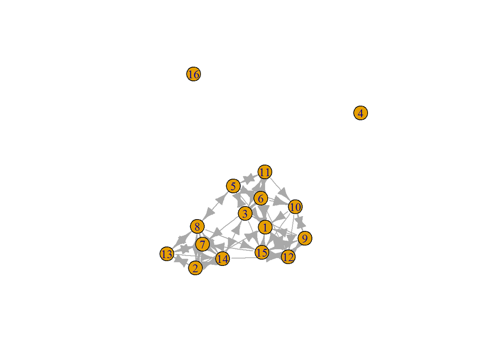

```r
plot(mFriend)
```

```r
(mFriend <- as.undirected(mFriend, mode = "collapse"))   #--- 무방향 그래프로 변경
```

```
## IGRAPH UN-- 16 42 --
## + attr: name (v/c)
## + edges (vertex names):
##  [1] 1 --2  1 --5  3 --5  1 --6  3 --6  5 --6  2 --7  6 --7  2 --8  5 --8
## [11] 7 --8  1 --9  3 --9  1 --10 5 --10 6 --10 9 --10 1 --11 3 --11 5 --11
## [21] 6 --11 10--11 1 --12 6 --12 9 --12 10--12 2 --13 7 --13 8 --13 2 --14
## [31] 3 --14 7 --14 8 --14 12--14 13--14 1 --15 3 --15 7 --15 8 --15 9 --15
## [41] 10--15 12--15
```

```r
(mFriend <- delete.vertices(mFriend, V(mFriend)[degree(mFriend) == 0]))   #--- 다른 vertex와 연결되지 않은 vertex 삭제
```

```
## IGRAPH UN-- 14 42 --
## + attr: name (v/c)
## + edges (vertex names):
##  [1] 1 --2  1 --5  3 --5  1 --6  3 --6  5 --6  2 --7  6 --7  2 --8  5 --8
## [11] 7 --8  1 --9  3 --9  1 --10 5 --10 6 --10 9 --10 1 --11 3 --11 5 --11
## [21] 6 --11 10--11 1 --12 6 --12 9 --12 10--12 2 --13 7 --13 8 --13 2 --14
## [31] 3 --14 7 --14 8 --14 12--14 13--14 1 --15 3 --15 7 --15 8 --15 9 --15
## [41] 10--15 12--15
```

```r
summary(mFriend)
```

```
## IGRAPH UN-- 14 42 --
## + attr: name (v/c)
```

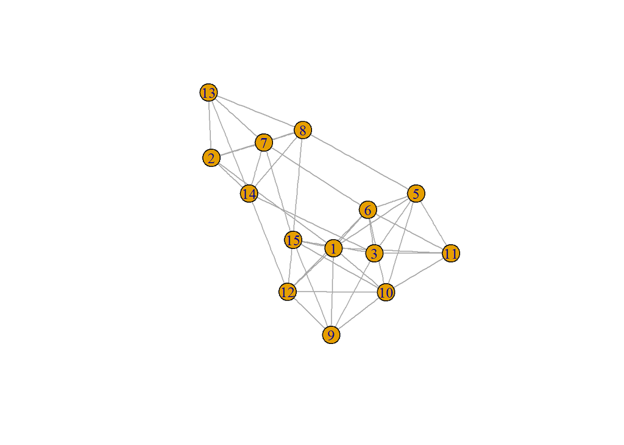

```r
plot(mFriend)
```

```r
#--- community detection : walktrap과 edge-betweenness 방법
#--- steps : random walks의 길이
#--- modularity = TRUE : modularity scores를 결과에 포함
(mFriend01 <- walktrap.community(mFriend, steps = 200, modularity = TRUE))
```

```
## IGRAPH clustering walktrap, groups: 3, mod: 0.099
## + groups:
##   $`1`
##   [1] "2"  "8"  "13"
##
##   $`2`
##   [1] "1"  "3"  "5"  "9"  "10" "12" "15"
##
##   $`3`
##   [1] "6"  "7"  "11" "14"
##
```

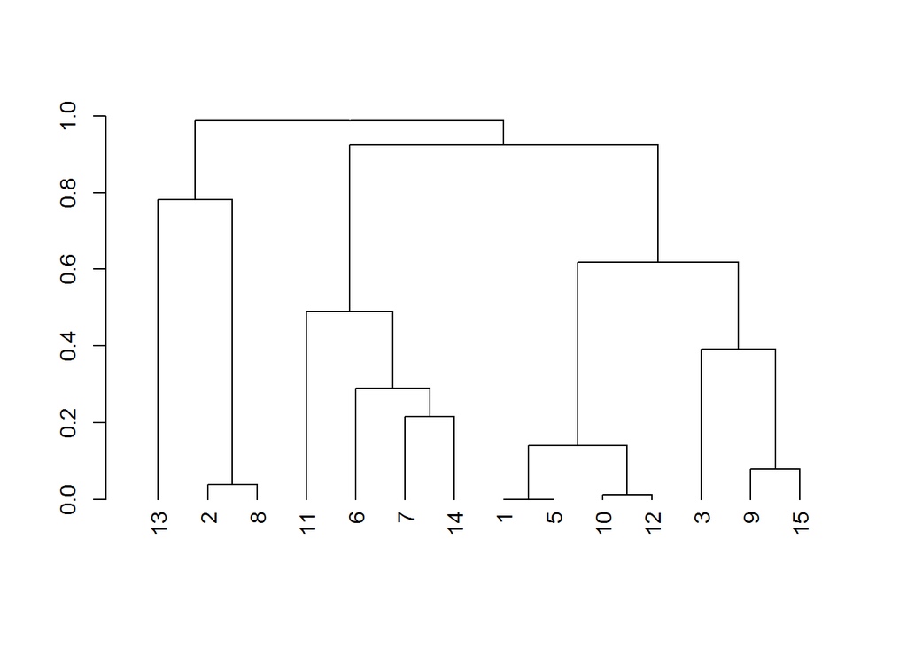

```r
plot(as.dendrogram(mFriend01, use.modularity = TRUE))    #--- 계층적 군집
```

```r
mFriend01$modularity
```

```
##  [1]  0.000000000 -0.063208610 -0.051303852 -0.035997730 -0.022108840
##  [6] -0.002267575  0.011337867  0.011337868  0.038548753  0.035430834
## [11]  0.064342402  0.099489793  0.079081655  0.000000000
```

### —————————————————————————–

### — Corpus에 저장된 데이터 분석

library(tm) (folder <- system.file(“texts”, “txt”, package = “tm”)) (doc <- Corpus(DirSource(folder), readerControl = list(language = “lat”))) rm(folder)

(doc <- tm_map(doc, stripWhitespace))[[1]] #— 두개 이상의 공백을 하나의 공백으로 치환 (doc <- tm_map(doc, tolower))[[1]] #— 소문자로 변환 (doc <- tm_map(doc, removePunctuation))[[1]] #— 구두점 삭제 (doc <- tm_map(doc, removeWords, stopwords(“english”)))[[1]] #— Stopword (조사, 띄어쓰기, 시제 등)를 제거하고 표준화 (doc <- tm_map(doc, stripWhitespace))[[1]] #— 두개 이상의 공백을 하나의 공백으로 치환 (doc <- tm_map(doc, stemDocument, language = “english”))[[1]] #— 어근만 추출 (m <- TermDocumentMatrix(doc)) #— Term Document Matrix 생성

(m2 <- as.matrix(m)) #— Matrix로 변환 (m2[m2 >= 1] <- 1) #— 0. 단어 미사용, 1. 단어 사용 m2[1:10, ]

(data <- m2[1:30, ] %*% t(m2[1:30, ])) #— 단어와 단어간의 관계로 변환 dim(data) #— 한 단어가 다른 단어와 얼마큼 함께 사용됐는지 확인 가능 head(data) rm(list = c(“m2”, “doc”))

library(igraph) (g <- graph.adjacency(data, weight = T, mode = “undirected”)) #— 방향성을 삭제한 인접(adjacency) 매트릭스 생성 (g <- simplify(g)) #— 그래프 단순화 vcount(g) #— Vertex 개수 V(g) #— Vertex ecount(g) #— Edge 개수 E(g) #— Edge

(V(g)$label <- V(g)$name) (V(g)$degree <- degree(g))

(layout1 <- layout.fruchterman.reingold(g)) #— 그래프를 그리기 위해 verticies의 위치를 결정 plot(g, layout = layout1)

V(g)$label.cex <- 2.2 * V(g)$degree / max(V(g)$degree) + .2 V(g)$label.color <- rgb(0, 0, .2, .8) V(g)$frame.color <- NA

(egam <- (log(E(g)$weight) + .4) / max(log(E(g)$weight) + .4)) E(g)$color <- rgb(.5, .5, 0, egam) E(g)$width <- egam plot(g, layout = layout1)

### —————————————————————————–

# — TermDocumentMatrix를 그래프로 분석

(g <- graph.incidence(m, mode = c(“all”))) (nTerms <- nrow(m)) #— 단어 수 (nDocs <- ncol(m)) #— 문서 수 idx.terms <- 1:nTerms idx.docs <- (nTerms + 1):(nTerms + nDocs)

V(g)$degree <- degree(g) V(g)$color[idx.terms] <- rgb(0, 1, 0, .5) V(g)$size[idx.terms] <- 6 V(g)$color[idx.docs] <- rgb(1, 0, 0, .4) V(g)$size[idx.docs] <- 4 V(g)$frame.color <- NA V(g)$label <- V(g)$name V(g)$label.color <- rgb(0, 0, 0, .5) V(g)$label.cex <- 1.4 * V(g)$degree / max(V(g)$degree) + 1 E(g)$width <- .3 E(g)$color <- rgb(.5, .5, 0, .3) plot(g, layout = layout.fruchterman.reingold) #— 아래 코드는 동작하지 않음 idx <- which(dimnames(data)$Terms %in% c(“r”, “data”, “mining”)) M <- data[-idx, ] tweetMatrix <- t(M) %*% M

g <- graph.adjacency(tweetMatrix, weight = T, mode = “undirected”) V(g)$degree <- degree(g) g <- simplify(g)

V(g)$label <- V(g)$name V(g)$label.cex <- 1 V(g)$label.color <- rgb(.4, 0, 0, .7) V(g)$size <- 2 V(g)$frame.color <- NA barplot(table(V(g)$degree))

idx <- V(g)$degree == 0 V(g)$label.color[idx] <- rgb(0, 0, .3, .7) V(g)$label[idx] <- paste(V(g)$name[idx], substr(df$text[idx], 1, 20), sep = “:”)

egam <- (log(E(g)$weight) + .2) / max(log(E(g)$weight) + .2)

E(g)$color <- rgb(.5, .5, 0, egam) E(g)$width <- egam layout2 <- layout.fruchterman.reingold(g) plot(g, layout = layout2)

g2 <- delete.vertices(g, V(g)[degree(g) == 0]) plot(g2, layout = layout.fruchterman.reingold)

g3 <- delete.edges(g, E(g)[E(g)$wieght <= 1]) g4 <- delete.vertices(g3, V(g3)[degree(g3) == 0]) plot(g4, layout = layout.fruchterman.reingold)

df$text[c(5, 19, 22, 23, 24, 28)] df$text[c(32, 34, 35, 40, 43, 46, 47, 85)]

```r
###-----------------------------------------------------------------------------
(data <- matrix(sample(0:1, 15, repl=TRUE), 3, 5))
```

```
##      [,1] [,2] [,3] [,4] [,5]
## [1,]    1    0    0    0    1
## [2,]    1    0    1    0    0
## [3,]    1    0    1    1    1
```

```r
colnames(data) <- letters[1:5]
rownames(data) <- LETTERS[1:3]
data
```

```
##   a b c d e
## A 1 0 0 0 1
## B 1 0 1 0 0
## C 1 0 1 1 1
```

```r
library(igraph)
(m <- graph.incidence(data, directed = FALSE))   #--- incidence. 발생
```

```
## IGRAPH UN-B 8 8 --
## + attr: type (v/l), name (v/c)
## + edges (vertex names):
## [1] A--a A--e B--a B--c C--a C--c C--d C--e
```

```r
vcount(m)                               #--- Vertex 개수
```

```
## [1] 8
```

```r
V(m)                                    #--- Vertex
```

```
## + 8/8 vertices, named:
## [1] A B C a b c d e
```

```r
ecount(m)                               #--- Edge 개수
```

```
## [1] 8
```

```r
E(m)                                    #--- Edge
```

```
## + 8/8 edges (vertex names):
## [1] A--a A--e B--a B--c C--a C--c C--d C--e
```

```r
data
```

```
##   a b c d e
## A 1 0 0 0 1
## B 1 0 1 0 0
## C 1 0 1 1 1
```

```r
(layouts <- layout.fruchterman.reingold(m))   #--- Fruchterman-Reingold Layout
```

```
##           [,1]     [,2]
## [1,] 10.766208 24.41925
## [2,]  8.368844 24.37385
## [3,]  9.661953 23.13142
## [4,]  9.560886 24.30294
## [5,]  9.928754 26.18261
## [6,]  8.418963 23.33425
## [7,]  9.800560 22.02510
## [8,] 10.888485 23.40825
```

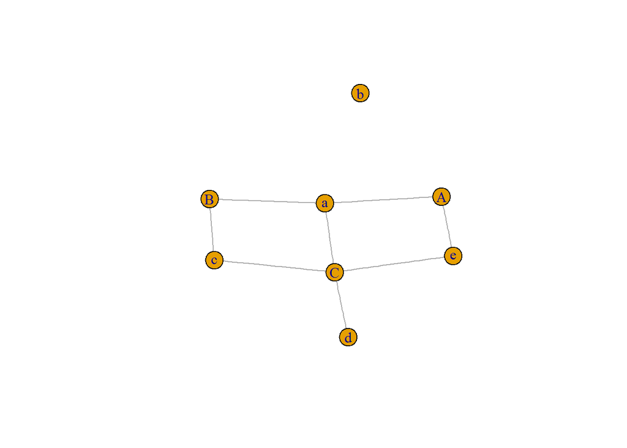

```r
plot(m, layout = layouts)
```

```r
###-----------------------------------------------------------------------------
search.term <- "#Rstats"
search.size <- 50
```

library(igraph) library(twitteR) search.results <- searchTwitter(search.term, n = search.size)

idx <- which(V(g)$name %in% c(“data”, “mining”)) g2 <- delete.vertices(g, V(g)[idx - 1]) g2 <- delete.vertices(g2, V(g2)[degree(g2) == 0]) plot(g2, layout = layout.fruchterman.reingold)

V1 <- vector() for (twt in search.results) { V1 <- c(v1, screenName(twt)) } v1 #— Page 714 colnames(v1) <- c(“user”, “tweets”) g <- graph.empty(directed = TRUE) g <- add.vertices(g, nrow(v1), name = as.character(v1$user, tweets = v1$tweets))

V(g)$followers <- 0 V(g)$tweets

getUser(“Biff_Bruise”)$getFollowers(n = 10)

for (use in V(g)) { tuser <- getUser(V(g)$name[usr + 1]) V(g)$followers[usr + 1] <- followersCount(tuser) followers.list <- getUser(V(g)$name[usr + 1])$getFollowers() for (tflwr in followers.list) { if (screenName(tflwr) %in% V(g)$name) { g <- add.edges(g, c(as.vector(V(g)[name = screenName(tflwr)]), usr)) } } }

g$layout <- layout.fruchterman.reingold(g) V(g)$size = log(V(g)$followers) * 1.8 V(g)$label = V(g)$name V(g)$label.cex = 0.6 tcolors <- rev(heat.colors(max(V(g)$tweets))) V(g)$color <- tcolors[V(g)$tweets] E(g)$arrow.size <- 0.3 E(g)$curved <- FALSE E(g)$color <- “blue” plot(g)

## 6. 예제

### —————————————————————————–

### Exercise 1

### —————————————————————————–

```r
###--- http://www.babelgraph.org/wp/?p=1
#data <- read.table("http://www.babelgraph.org/data/ga_edgelist.csv", header=TRUE, sep=",",
#                   stringsAsFactors=FALSE, na.strings=c('NIL'),
#                   comment.char="#", encoding="UTF-8")
#write.table(data, file="data/ADV_4_5_005.csv", append=FALSE, quote=TRUE, sep=",", row.names=FALSE)
#--- 그레이 아나토미에 등장했던 여러 주인공들 간의 연인 관계 데이터
(data <- read.table("data/ADV_4_5_005.csv", header=TRUE, sep=",", quote="\"",
                    stringsAsFactors=FALSE, na.strings=c('NIL'),
                    comment.char="#", encoding="UTF-8"))
```

```
##          from           to
## 1        lexi        sloan
## 2        lexi        karev
## 3        owen         yang
## 4        owen       altman
## 5       sloan       torres
## 6       sloan       altman
## 7      torres      arizona
## 8      torres        karev
## 9       derek         grey
## 10      karev        izzie
## 11   o'malley        izzie
## 12     torres     o'malley
## 13       yang        colin
## 14       yang      preston
```

[output cut: 20 more lines]

```r
library(igraph)
(g <- graph.data.frame(data, directed = FALSE))
```

```
## IGRAPH UN-- 32 34 --
## + attr: name (v/c)
## + edges (vertex names):
##  [1] lexi    --sloan        lexi    --karev        owen    --yang
##  [4] owen    --altman       sloan   --torres       sloan   --altman
##  [7] torres  --arizona      torres  --karev        derek   --grey
## [10] karev   --izzie        o'malley--izzie        torres  --o'malley
## [13] yang    --colin        yang    --preston      karev   --kepner
## [16] sloan   --addison      karev   --addison      derek   --addison
## [19] sloan   --nancy        karev   --olivia       o'malley--olivia
## [22] o'malley--grey         karev   --mrs. seabury chief   --adele
## + ... omitted several edges
```

```r
summary(g)
```

```
## IGRAPH UN-- 32 34 --
## + attr: name (v/c)
```

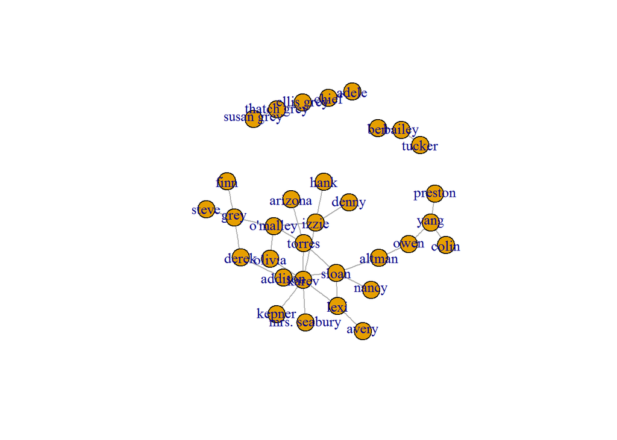

```r
g$layout <- layout.fruchterman.reingold(g)
plot(g)
```

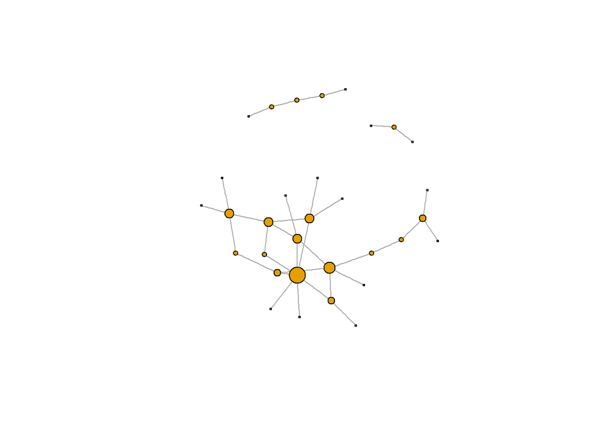

```r
V(g)$label <- NA                        #--- 레이블 삭제
V(g)$size <- degree(g) * 2
plot(g)
```

```r
(clo <- closeness(g))
```

```
##         lexi         owen        sloan       torres        derek
##  0.003115265  0.002898551  0.003174603  0.003194888  0.003039514
##        karev     o'malley         yang         grey        chief
##  0.003174603  0.003134796  0.002754821  0.003003003  0.001148106
##   ellis grey   susan grey       bailey        izzie       altman
##  0.001149425  0.001144165  0.001075269  0.003076923  0.003039514
##      arizona        colin      preston       kepner      addison
##  0.002985075  0.002597403  0.002597403  0.002967359  0.003174603
##        nancy       olivia mrs. seabury        adele  thatch grey
##  0.002967359  0.003039514  0.002967359  0.001144165  0.001148106
##       tucker         hank        denny         finn        steve
##  0.001074114  0.002881844  0.002881844  0.002816901  0.002816901
##          ben        avery
##  0.001074114  0.002915452
```

```r
(clo.score <- round((clo - min(clo)) * length(clo) / max(clo)) + 1)
```

```
##         lexi         owen        sloan       torres        derek
##           21           19           22           22           21
##        karev     o'malley         yang         grey        chief
##           22           22           18           20            2
##   ellis grey   susan grey       bailey        izzie       altman
##            2            2            1           21           21
##      arizona        colin      preston       kepner      addison
##           20           16           16           20           22
##        nancy       olivia mrs. seabury        adele  thatch grey
##           20           21           20            2            2
##       tucker         hank        denny         finn        steve
##            1           19           19           18           18
##          ben        avery
##            1           19
```

```r
(clo.colors <- rev(heat.colors(max(clo.score))))
```

```
##  [1] "#FFFFE6FF" "#FFFFB3FF" "#FFFF80FF" "#FFFF4DFF" "#FFFF19FF"
##  [6] "#FFFF00FF" "#FFEF00FF" "#FFDF00FF" "#FFCF00FF" "#FFBF00FF"
## [11] "#FFAF00FF" "#FF9F00FF" "#FF8F00FF" "#FF8000FF" "#FF7000FF"
## [16] "#FF6000FF" "#FF5000FF" "#FF4000FF" "#FF3000FF" "#FF2000FF"
## [21] "#FF1000FF" "#FF0000FF"
```

```r
(V(g)$color <- clo.colors[clo.score])
```

```
##  [1] "#FF1000FF" "#FF3000FF" "#FF0000FF" "#FF0000FF" "#FF1000FF"
##  [6] "#FF0000FF" "#FF0000FF" "#FF4000FF" "#FF2000FF" "#FFFFB3FF"
## [11] "#FFFFB3FF" "#FFFFB3FF" "#FFFFE6FF" "#FF1000FF" "#FF1000FF"
## [16] "#FF2000FF" "#FF6000FF" "#FF6000FF" "#FF2000FF" "#FF0000FF"
## [21] "#FF2000FF" "#FF1000FF" "#FF2000FF" "#FFFFB3FF" "#FFFFB3FF"
## [26] "#FFFFE6FF" "#FF3000FF" "#FF3000FF" "#FF4000FF" "#FF4000FF"
## [31] "#FFFFE6FF" "#FF3000FF"
```

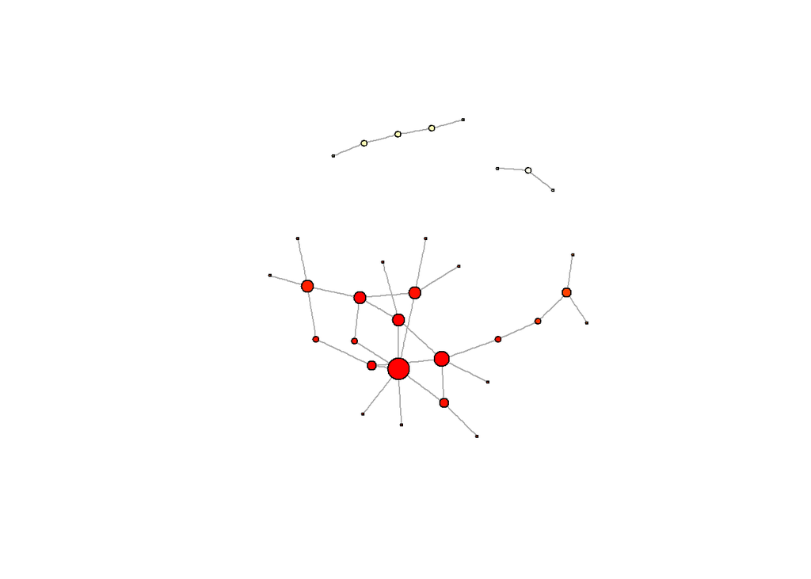

```r
plot(g)
```

```r
(btw <- betweenness(g))
```

```
##         lexi         owen        sloan       torres        derek
##     36.00000     60.00000    115.36667     67.15000     17.95000
##        karev     o'malley         yang         grey        chief
##     95.26667     54.41667     43.00000     46.86667      3.00000
##   ellis grey   susan grey       bailey        izzie       altman
##      4.00000      0.00000      1.00000     47.95000     76.00000
##      arizona        colin      preston       kepner      addison
##      0.00000      0.00000      0.00000      0.00000     44.08333
##        nancy       olivia mrs. seabury        adele  thatch grey
##      0.00000      4.95000      0.00000      0.00000      3.00000
##       tucker         hank        denny         finn        steve
##      0.00000      0.00000      0.00000      0.00000      0.00000
##          ben        avery
##      0.00000      0.00000
```

```r
(btw.score <- round(btw) + 1)
```

```
##         lexi         owen        sloan       torres        derek
##           37           61          116           68           19
##        karev     o'malley         yang         grey        chief
##           96           55           44           48            4
##   ellis grey   susan grey       bailey        izzie       altman
##            5            1            2           49           77
##      arizona        colin      preston       kepner      addison
##            1            1            1            1           45
##        nancy       olivia mrs. seabury        adele  thatch grey
##            1            6            1            1            4
##       tucker         hank        denny         finn        steve
##            1            1            1            1            1
##          ben        avery
##            1            1
```

```r
(btw.colors <- rev(heat.colors(max(btw.score))))
```

```
##   [1] "#FFFFFBFF" "#FFFFF2FF" "#FFFFE9FF" "#FFFFE0FF" "#FFFFD7FF"
##   [6] "#FFFFCFFF" "#FFFFC6FF" "#FFFFBDFF" "#FFFFB4FF" "#FFFFABFF"
##  [11] "#FFFFA3FF" "#FFFF9AFF" "#FFFF91FF" "#FFFF88FF" "#FFFF80FF"
##  [16] "#FFFF77FF" "#FFFF6EFF" "#FFFF65FF" "#FFFF5CFF" "#FFFF54FF"
##  [21] "#FFFF4BFF" "#FFFF42FF" "#FFFF39FF" "#FFFF30FF" "#FFFF28FF"
##  [26] "#FFFF1FFF" "#FFFF16FF" "#FFFF0DFF" "#FFFF04FF" "#FFFF00FF"
##  [31] "#FFFC00FF" "#FFF900FF" "#FFF600FF" "#FFF300FF" "#FFF000FF"
##  [36] "#FFED00FF" "#FFEA00FF" "#FFE700FF" "#FFE400FF" "#FFE100FF"
##  [41] "#FFDE00FF" "#FFDB00FF" "#FFD800FF" "#FFD500FF" "#FFD300FF"
##  [46] "#FFD000FF" "#FFCD00FF" "#FFCA00FF" "#FFC700FF" "#FFC400FF"
##  [51] "#FFC100FF" "#FFBE00FF" "#FFBB00FF" "#FFB800FF" "#FFB500FF"
##  [56] "#FFB200FF" "#FFAF00FF" "#FFAC00FF" "#FFA900FF" "#FFA600FF"
##  [61] "#FFA300FF" "#FFA000FF" "#FF9D00FF" "#FF9A00FF" "#FF9700FF"
##  [66] "#FF9400FF" "#FF9100FF" "#FF8E00FF" "#FF8B00FF" "#FF8800FF"
##  [71] "#FF8500FF" "#FF8200FF" "#FF8000FF" "#FF7D00FF" "#FF7A00FF"
##  [76] "#FF7700FF" "#FF7400FF" "#FF7100FF" "#FF6E00FF" "#FF6B00FF"
##  [81] "#FF6800FF" "#FF6500FF" "#FF6200FF" "#FF5F00FF" "#FF5C00FF"
##  [86] "#FF5900FF" "#FF5600FF" "#FF5300FF" "#FF5000FF" "#FF4D00FF"
##  [91] "#FF4A00FF" "#FF4700FF" "#FF4400FF" "#FF4100FF" "#FF3E00FF"
##  [96] "#FF3B00FF" "#FF3800FF" "#FF3500FF" "#FF3200FF" "#FF2F00FF"
## [101] "#FF2C00FF" "#FF2A00FF" "#FF2700FF" "#FF2400FF" "#FF2100FF"
## [106] "#FF1E00FF" "#FF1B00FF" "#FF1800FF" "#FF1500FF" "#FF1200FF"
## [111] "#FF0F00FF" "#FF0C00FF" "#FF0900FF" "#FF0600FF" "#FF0300FF"
## [116] "#FF0000FF"
```

```r
(V(g)$color <- btw.colors[btw.score])
```

```
##  [1] "#FFEA00FF" "#FFA300FF" "#FF0000FF" "#FF8E00FF" "#FFFF5CFF"
##  [6] "#FF3B00FF" "#FFB500FF" "#FFD500FF" "#FFCA00FF" "#FFFFE0FF"
## [11] "#FFFFD7FF" "#FFFFFBFF" "#FFFFF2FF" "#FFC700FF" "#FF7400FF"
## [16] "#FFFFFBFF" "#FFFFFBFF" "#FFFFFBFF" "#FFFFFBFF" "#FFD300FF"
## [21] "#FFFFFBFF" "#FFFFCFFF" "#FFFFFBFF" "#FFFFFBFF" "#FFFFE0FF"
## [26] "#FFFFFBFF" "#FFFFFBFF" "#FFFFFBFF" "#FFFFFBFF" "#FFFFFBFF"
## [31] "#FFFFFBFF" "#FFFFFBFF"
```

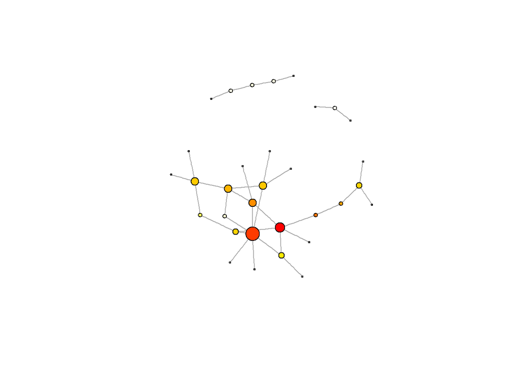

```r
plot(g)
```

```r
#--- Girvan-Newman algorithm
#---     http://en.wikipedia.org/wiki/Girvan%E2%80%93Newman_algorithm
(gnc <- edge.betweenness.community(g, directed = FALSE))
```

```
## IGRAPH clustering edge betweenness, groups: 7, mod: 0.58
## + groups:
##   $`1`
##   [1] "lexi"         "sloan"        "karev"        "kepner"
##   [5] "addison"      "nancy"        "mrs. seabury" "avery"
##
##   $`2`
##   [1] "owen"    "yang"    "altman"  "colin"   "preston"
##
##   $`3`
##   [1] "torres"   "o'malley" "arizona"  "olivia"
##
##   + ... omitted several groups/vertices
```

```r
(m <- vector())
```

```
## logical(0)
```

### —————————————————————————–

### Exercise 2

### —————————————————————————–

library(twitteR) rdmTweets <- userTimeline(“rdatamining”, n = 2000) #— Tweet 가져오기 (data <- do.call(“rbind”, lapply(rdmTweets, as.data.frame))) (doc <- Corpus(VectorSource(data$text)))

library(tm) (doc <- tm_map(doc, tolower))[[1]] #— 소문자로 변환 (doc <- tm_map(doc, removePunctuation))[[1]] #— 구두점 삭제 (doc <- tm_map(doc, removeNumbers))[[1]] #— 숫자 삭제

removeURL <- function(x) gsub(“http[[:alnum:]]*“,”“, x) (doc <- tm_map(doc, removeURL))[[1]] #— URL 삭제 rm(removeURL)

(myStopwords <- c(stopwords(“english”), “available”, “via”)) (idx <- which(myStopwords %in% c(“r”, “big”))) (myStopwords <- myStopwords[-idx]) (doc <- tm_map(doc, removeWords, myStopwords))[[1]] #— Stopword (조사, 띄어쓰기, 시제 등)를 제거하고 표준화 rm(myStopwords)

docOrg <- doc (doc <- tm_map(doc, stemDocument))[[1]] #— 어근만 추출

(doc <- tm_map(doc, stemCompletion, dictionary = docOrg))[[1]] #— 어근으로 원래 단어 유추 inspect(doc[11:15])

library(ggplot2) qplot(names(termFrequency), termFrequency, geom = “bar”) + coord_flip() barplot(termFrequency, las = 2)

findAssocs(m, “data”, 0.25) findAssocs(m, “mining”, 0.25)

library(wordcloud) m <- as.matrix(m) wordFreq <- sort(rowSums(m), decreasing = TRUE) grayLevels <- gray((wordFreq + 10) / (max(wordFreq) + 10)) wordcloud(words = names(wordFreq), freq = wordFreq, min.freq = 3, random.order = F, colors = grayLevels)

myTdm2 <- removeSparseTerms(m, sparse = 0.95) m2 <- as.matrix(myTdm2) distMatrix <- dist(scale(m2))

fit <- hclust(distMatrix, method = “ward”) plot(fit) rect.hclust(fit, k = 10)

(groups <- cutree(fit, k = 10))

m3 <- t(m2) k <- 8 kmeansResult <- kmeans(m3, k) round(kmeansResult$centers, digit = 3)

for (i in 1:k) { cat(paste(“cluster”, i, “:”, sep = “”)) s <- sort(kmeansResult$centers[i,], decreasing = T) cat(names(s)[1:3], “”) }

library(fpc) pamResult <- pamk(m3, metric = “manhatttan”) (k <- pamResult$nc)

pamResult <- pamResult$pamobject for (i in 1:k) { cat(paste("cluster", i, ": ")) cat(colnames(pamResult$medoids)[which(pamResult$medoids[i, ] == 1)], “”) } layout(matrix(c(1, 2), 2, 1)) plot(pamResult, color = F, labels = 4, lines = 0, cex = .8, col.clus = 1, col.p = pamResult$clustering) layout(matrix(1))

rm(list=ls(all=TRUE)) #— 작업 영역에 저장된 데이터 모두 삭제

### —————————————————————————–

### 트위터 인증 정보 생성 및 사용하기

### —————————————————————————–

library(twitteR) requestURL = “http://api.twitter.com/oauth/request_token” accessURL = “https://api.twitter.com/oauth/access_token” authURL = “https://api.twitter.com/oauth/authorize”

comsumerKey = “” consumerSecret = “”

library(ROAuth) twitterCred <- OAuthFactory$new(  
consumerKey = consumerKey, consumerSecret = consumerSecret, requestURL = requestURL, accessURL = accessURL, authURL = authURL ) #— 결과 화면에 표시되는 https 사이트로 브라우저에서 접속 합니다. #— 애플리케이션을 인증하고 PIN 번호를 확인 합니다.

download.file(url = “http://curl.haxx.se/ca/cacert.pem”, destfile = “cacert.pem”)

twitterCred$handshake(cainfo = “cacert.pem”) #— 입력 화면에서 위에서 받은 PIN 번호를 입력 합니다.

save(list = “twitterCred”, file = “twitteR_credentials”)

load(“twitteR_credentials”) library(twitteR) registerTwitterOAuth(twitterCred)

library(twitteR) #— @hilton을 언급한 최대 1500 tweet 가져오기 (doc <- searchTwitter("@hilton", n = 1500, cainfo = “cacert.pem”))  
length(doc) doc[1:5]

tweet <- doc[[1]] #— 첫번째 트윗 가져오기 tweet$getScreenName() tweet$getText()

library(plyr) doc.text <- laply(doc, function(t) { t$getText() }) #– 트윗에서 텍스트만 추출

doc.text <- doc.text[!Encoding(doc.text) == “UTF-8”] doc.scores <- scores(doc.text, pos.words, neg.words, .progress = “text”) hist(doc.scores$score)

doc.scores$hotel = "Hilton" doc.scores$code = “HL” library(ggplot2) qplot(doc.scores$score)

intercontinental.tweets = searchTwitter('@interconhotels', n = 1500) intercontinental.text = laply(intercontinental.tweets, function(t) { return t$getText()}) intercontinental.scores = scores(intercontinental.text, pos.words, neg.words, .progress = 'text') intercontinental.scores$hotel = “intercontinental” intercontinental.scores$code = “IC”

rm(list=ls(all=TRUE)) #— 작업 영역에 저장된 데이터 모두 삭제

### —————————————————————————–

### 페이스북 인증 정보 생성 및 사용하기

### —————————————————————————–

### — 반드시 R GUI 환경에서 실행하여야 합니다.

(me <- getUsers(“me”, token = fb_oauth)) (my_friends <- getFriends(token = fb_oauth, simplify = TRUE)) (my_friends_info <- getUsers(my_friends$id, token = fb_oauth, private_info = TRUE)) (my_network <- getNetwork(token = fb_oauth, format = "edgelist", verbose = TRUE)) colnames(my_friends_info) table(my_friends_info$relationship_status) head(my_network)

library(igraph) a2 <- data.frame(a) g <- graph.data.frame(a) g$layout <- layout.fruchterman.reingold(g) V(a3)$label <- NA V(a3)$width <- 0.1 plot(a3, edge.arrow.size = 0.1, vertex.size = 5)

hi <- grep(“정민지”, dfa$X1) hi2 <- grep("권도연", dfa$X1) hi3 <- grep(“JongWoong Park”, dfa$X1) k <- dfa[hi,] j <- dfa[hi2, ] y <- dfa[hi3, ] kj <- rbind(k, j, y)

b <- data.frame(kj) b2 <- graph.data.frame(b) b2$layout <- layout.fruchterman.reingold(b2) plot(b2, edge.arrow.size = .3, vertex.size = 1)

rm(list=ls(all=TRUE)) #— 작업 영역에 저장된 데이터 모두 삭제 ###—————————————————————————–